# Higher Education Regression Analysis

Lillian P. Lema

## Introduction

Utilizing an extensive dataset obtained from the Department of Education, covering all higher education institutions in 2023, the aim is to analyze the diverse range of factors impacting graduation rates. The dataset utilized for this analysis contains 6,352 rows and 78 columns, featuring information ranging from school names, tuition fees, geographical location, and demographic proportions to SAT averages, admission rates, financial aid statistics, and much more. The preparation for analyzing this dataset included simplifying and renaming columns for comprehensive purposes, removing columns that weren’t relevant to this exploration. Rows with missing data (NAs) were removed from the dataset before each analysis question was explored, not at the beginning when the dataset was initially prepared. This approach ensures that no important data related to the specific variable being studied is lost. Additionally, new data frames and columns were created for this analysis.

In this assignment, the focus is on consolidating theoretical knowledge into practical skills with the application of Ridge and LASSO regression techniques. The goal is to build linear and logistic models by implementing Ridge and LASSO functions over a range of regularization parameter lambda values. The assignment entails the creation of two regularized models: a regression model predicting Completion Rate (`C150_4_L4`), and a logistic regression model predicting `Completion Rate Median` and `Completion Rate High` columns.

Ridge and LASSO are regularization techniques used to prevent overfitting in statistical models by adding a penalty term to the cost function. Ridge regression adds a penalty equivalent to the square of the magnitude of coefficients, while LASSO adds a penalty equivalent to the absolute value of the magnitude of coefficients. The main difference between the two lies in the penalty term: Ridge tends to shrink coefficients towards zero, while LASSO tends to set some coefficients to exactly zero, effectively performing variable selection.

Additionally, outliers are identified and removed using Mahalanobis Distance and Local Outlier Factor methods. Ridge regression is then applied, estimating lambda.min and lambda.1se values and fitting the model against the training set to report interesting findings and performance metrics. Similarly, LASSO regression is applied to the training set, with focus on reporting coefficients and identifying any coefficients that reduce to zero.

By comparing the performance of the Ridge and LASSO models, insights can be gained into which regularization technique better suits the dataset and the predictive task at hand. This comparison will shed light on the effectiveness of each method and whether the outcomes align with expectations.

```r
# Week 5

# Importing and preparing the dataset

CollegeDataset <- read_csv("college_scorecard_Short1.csv")
# Clean names

clean_names(CollegeDataset)

# Column Names

colnames(CollegeDataset)

# Learn about the dataset

dim(CollegeDataset) # checking dimensions of the dataset

summary(CollegeDataset)

# Checking the structure of the dataset

str(CollegeDataset)

skim(CollegeDataset)

# Checking for NAs in columns

colSums(is.na(CollegeDataset))
# Various columns have a decent amount of NAs

# Removing NAs from response (dependent) variables

# Completion_Rate

CollegeDataset <- CollegeDataset %>% drop_na(C150_4_L4)

# Completion_Rate_Median

CollegeDataset <- CollegeDataset %>% drop_na(Completion_Rate_Median)

# Completion_Rate_High

CollegeDataset <- CollegeDataset %>% drop_na(Completion_Rate_High)

# Checking dimensions now after NA removal

dim(CollegeDataset)
```

## Variable Selection

To ensure the robustness and efficiency of the analysis, a systematic process of variable selection was conducted on the dataset obtained from the Department of Education. Initially, a comprehensive missing data report (Figure 1) was generated to understand the extent of missing values in the dataset. After removing NAs from the three response variables `C150_4_L4`, `Completion Rate Median`, and `Completion Rate High`, the dataset decreased to 5242 observations with 78 columns.

To streamline the dataset while retaining its informative value, columns with more than 300 missing values were eliminated, resulting in the removal of 21 columns. This step reduced the dataset to 5242 rows and 57 columns, minimizing the impact of missing data on subsequent analyses. Further refinement was undertaken by selecting columns based on their relevance to the analysis objectives and the least amount of missing data. This process resulted in the creation of a subset, `CollegeDataset2`, containing 5242 observations across 13 carefully chosen columns. These columns include essential predictor variables such as enrollment demographics (`UG25ABV`, `UGDS`, `UGDS_WHITE`, `UGDS_BLACK`, `UGDS_HISP`, and `UGDS_ASIAN`), metrics related to financial aid (`PCTPELL` and `PCTFLOAN`), and various institutional characteristics (`HIGHDEG` and `NUMBRANCH`).

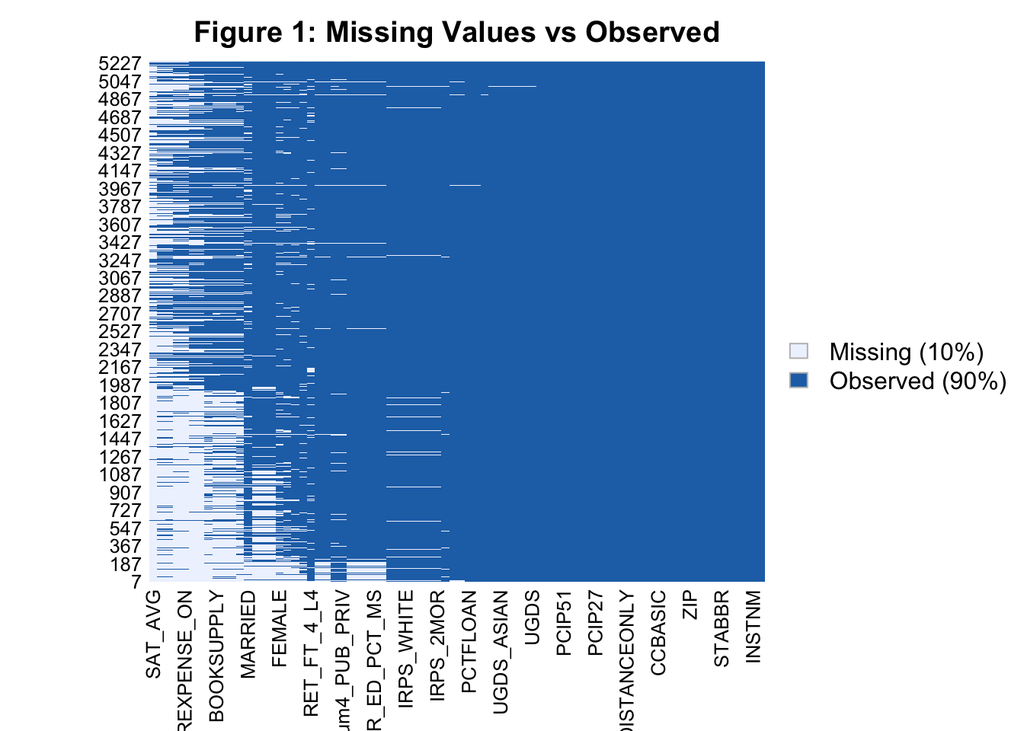

```r
# ------------------------------------
# Generate a missing data report
# ------------------------------------

missmap(CollegeDataset, main = "Figure 1: Missing Values vs Observed")
```

```r
# Currently the CollegeDataset has 5242 rows and 78 columns

# ------------------------------------
# List columns with most missing values
# ------------------------------------

sort(colSums(is.na(CollegeDataset)), decreasing = TRUE)

# SAT_AVG             ADM_RATE                ADMCON7           ROOMBOARD_ON
# 4219                   3385                   3373                   3313
# OTHEREXPENSE_ON     ENDOWBEGIN               ENDOWEND               PFTFAC
# 3310                   2856                   2856                   2095
# BOOKSUPPLY          TUITIONFEE_IN         TUITIONFEE_OUT          AVGFACSAL
# 2027                   1982                   1982                   1833
# MARRIED          MEDIAN_HH_INC           POVERTY_RATE             UNEMP_RATE
# 925                    904                    904                    904
# FEMALE              FIRST_GEN              DEPENDENT        MD_EARN_WNE_1YR
# 897                    741                    509                    429
# RET_FT_4_L4         AGE_ENTRY                 FAMINC             COSTT4_A_P
# 397                    225                    225                    212
# Num4_PUB_PRIV      PAR_ED_PCT_1STGEN          PAR_ED_PCT_MS          PAR_ED_PCT_HS
# 208                    207                    207                    207
# DEP_INC_AVG         APPL_SCH_N              IRPS_2MOR             IRPS_ASIAN
# 207                    207                    123                    123
# IRPS_BLACK          IRPS_HISP             IRPS_WHITE             IRPS_WOMEN
# 123                    123                    123                    123
# IRPS_MEN              UG25ABV          GRAD_DEBT_MDN         WDRAW_DEBT_MDN
# 123                     81                     50                     50
# PCTPELL             PCTFLOAN                SCHTYPE                STUFACR
# 8                      8                      7                      4
# UGDS             UGDS_WHITE             UGDS_BLACK              UGDS_HISP
# 2                      2                      2                      2
# UGDS_ASIAN          PCIP09                 PCIP11                 PCIP13
# 2                     1                      1                      1
# PCIP27              PCIP40                 PCIP41                 PCIP42
# 1                      1                      1                      1
# PCIP51                PCIP52                TUITFTE               INEXPFTE
# 1                      1                      1                      1

# ------------------------------------
# Eliminate columns with more than 300 missing values
# Note that the number 300 is chosen rather arbitrarily because it feels like
# a decent amount of NAs for the columns to have with out loosing too much valuable data
# ------------------------------------

CollegeDataset = CollegeDataset[, colSums(is.na(CollegeDataset)) < 300]

# dim(CollegeDataset) # 5242 by 57 columns meaning that 21 columns were removed

sort(colSums(is.na(CollegeDataset)), decreasing = TRUE)

# These are the remaining columns
# AGE_ENTRY            FAMINC             COSTT4_A_P          Num4_PUB_PRIV
# 225                    225                    212                    208
# PAR_ED_PCT_1STGEN   PAR_ED_PCT_MS          PAR_ED_PCT_HS            DEP_INC_AVG
# 207                    207                    207                    207
# APPL_SCH_N            IRPS_2MOR             IRPS_ASIAN             IRPS_BLACK
# 207                    123                    123                    123
# IRPS_HISP             IRPS_WHITE             IRPS_WOMEN               IRPS_MEN
# 123                    123                    123                    123
# UG25ABV          GRAD_DEBT_MDN         WDRAW_DEBT_MDN                PCTPELL
# 81                     50                     50                      8
# PCTFLOAN                SCHTYPE                STUFACR              UGDS
# 8                      7                      4                      2
# UGDS_WHITE             UGDS_BLACK              UGDS_HISP             UGDS_ASIAN
# 2                      2                      2                      2
# PCIP09                 PCIP11                 PCIP13                 PCIP27
# 1                      1                      1                      1
# PCIP40                 PCIP41                 PCIP42                 PCIP51
# 1                      1                      1                      1
# PCIP52                TUITFTE               INEXPFTE                ICLEVEL
# 1                      1                      1                      0
# INSTNM                 REGION                 LOCALE                   CITY
# 0                      0                      0                      0
# STABBR              C150_4_L4 Completion_Rate_Median   Completion_Rate_High
# 0                      0                      0                      0
# ZIP              NUMBRANCH                PREDDEG                HIGHDEG
# 0                      0                      0                      0
# CCBASIC               CCUGPROF               CCSIZSET                   HBCU
# 0                      0                      0                      0
# DISTANCEONLY
# 0

# colnames(CollegeDataset)

# str(CollegeDataset)

# ------------------------------------
# Keep the following columns and create a subset
# This is the first pass of shortening the dataframe
# Choose predictor variables based on the areas of interest and least amount of NAs
# ------------------------------------

CollegeDataset2 = CollegeDataset[, c("C150_4_L4","Completion_Rate_Median",
                                     "Completion_Rate_High",
                                    "NUMBRANCH",
                                    "UG25ABV",
                                    "HIGHDEG",
                                    "UGDS",
                                    "UGDS_WHITE",
                                    "UGDS_BLACK",
                                    "UGDS_HISP",
                                    "UGDS_ASIAN",
                                    "PCTPELL",
                                    "PCTFLOAN")]

# Convert HIGHDEG numbers to categories

CollegeDataset2$HIGHDEG <- factor(CollegeDataset2$HIGHDEG, levels = 0:4,
                                  labels = c("Non-Degree-Granting", "Certificate Degree",
                                             "Associate Degree", "Bachelors Degree",
                                             "Graduate Degree"))

dim(CollegeDataset2) # 5242 observations with 13 columns

sort(colSums(is.na(CollegeDataset2)), decreasing = TRUE)

# PCTPELL               PCTFLOAN             UGDS_WHITE             UGDS_BLACK
# 8                      8                      2                      2
# UGDS_HISP             UGDS_ASIAN            C150_4_L4  Completion_Rate_Median
# 2                      2                      0                      0
# Completion_Rate_High  NUMBRANCH             UGDS                 STABBR
# 0                      0                      2                     0
# HIGHDEG     UG25ABV
# 0              81

# remove missing values

CollegeDataset2 = na.omit(CollegeDataset2)

# dim(CollegeDataset2) # 5154 observations with 13 columns
```

To ensure interpretability and ease of analysis, certain categorical variables were transformed into factor variables. Notably, the variable `HIGHDEG`, representing the highest degree awarded by institutions, was categorized into meaningful labels: “Non-Degree-Granting”, “Certificate Degree”, “Associate Degree”, “Bachelors Degree”, and “Graduate Degree.”

After variable selection and transformation, the resulting dataset, `CollegeDataset2`, comprised 5154 observations with 13 columns. This meticulous process of variable selection guarantees the integrity and relevance of the dataset for future analyses, facilitating meaningful insights into the factors influencing graduation rates in higher education institutions.

## Removing Outliers

To initiate this analysis, outliers were identified and removed from the dataset using two distinct methods: Mahalanobis Distance and Local Outlier Factor (LOF). These methods provide valuable insights into data points that deviate significantly from the majority, assisting in the creation of robust statistical models.

### Mahalanobis Distance

The Mahalanobis Distance method detects outliers based on the calculated distance of each data point from the centroid of the dataset, accounting for the covariance structure of the variables. For this analysis, the numeric columns relevant to the study, namely `C150_4_L4`, `NUMBRANCH`, `UG25ABV`, `UGDS`, `UGDS_WHITE`, `PCTPELL`, `PCTFLOAN`, `UGDS_BLACK`, `UGDS_HISP`, and `UGDS_ASIAN`, were selected.

```r
# print types of columns in college dataset 2

# sapply(CollegeDataset2, class) # Not all numeric

# Use mahalanobis distance to detect outliers, based on the following numeric columns:
# -------------------------------------------------------------------------
# "C150_4_L4"   "NUMBRANCH"   "UGD" "UGDS_WHITE"  "PCTPELL" "PCTFLOAN"
# "UGDS_BLACK"  "UGDS_HISP"             "UGDS_ASIAN"  "UG25ABV"
# -------------------------------------------------------------------------

listofcols = c("C150_4_L4","NUMBRANCH", "UG25ABV", "UGDS", "UGDS_WHITE",
               "PCTPELL","PCTFLOAN","UGDS_BLACK","UGDS_HISP","UGDS_ASIAN")

# check if the columns in the list are numeric

# sapply(CollegeDataset2[, listofcols], class) #All numeric

# Use mahalanobis distance to detect outliers

outliers = mahalanobis(CollegeDataset2[, listofcols],
                       colMeans(CollegeDataset2[, listofcols]),
                       cov(CollegeDataset2[, listofcols]))
# print(outliers)

# Use the quantile function to find the 95th percentile of the mahalanobis distance
# The ones above this value are the outliers

Outlier_Threshold = quantile(outliers, 0.95)

# print(Outlier_Threshold) # 26.05974

# print the outliers

# dim(CollegeDataset2[outliers > Outlier_Threshold, ]) # 258 outliers

# Create a colunm to identify the outliers

CollegeDataset2$Outliers_Maha = ifelse(outliers > Outlier_Threshold, 1, 0)

# Print first 6 rows

Outlier_Maha_College2_6 <- head(CollegeDataset2)

# Present as a nice table

knitr::kable(Outlier_Maha_College2_6, caption =
               "College Dataset w/ Outliers (Mahalanobis Distance)")
```

College Dataset w/ Outliers (Mahalanobis Distance)

| C150_4_L4 | Completion_Rate_Median | Completion_Rate_High | NUMBRANCH | UG25ABV | HIGHDEG | UGDS | UGDS_WHITE | UGDS_BLACK | UGDS_HISP | UGDS_ASIAN | PCTPELL | PCTFLOAN | Outliers_Maha |
| --- | --- | --- | --- | --- | --- | --- | --- | --- | --- | --- | --- | --- | --- |
| 0.2807 | Below Median | Other | 1 | 0.0617 | Graduate Degree | 5098 | 0.0184 | 0.8978 | 0.0114 | 0.0014 | 0.6853 | 0.6552 | 0 |
| 0.6245 | Above Median | Other | 1 | 0.1794 | Graduate Degree | 13284 | 0.5297 | 0.2458 | 0.0669 | 0.0767 | 0.3253 | 0.4401 | 0 |
| 0.4444 | Below Median | Other | 1 | 0.8606 | Graduate Degree | 251 | 0.2470 | 0.6932 | 0.0438 | 0.0000 | 0.7852 | 0.8423 | 0 |
| 0.6072 | Above Median | Other | 1 | 0.1519 | Graduate Degree | 7358 | 0.7196 | 0.0871 | 0.0610 | 0.0357 | 0.2377 | 0.3578 | 0 |
| 0.2843 | Below Median | Other | 1 | 0.0677 | Graduate Degree | 3495 | 0.0152 | 0.9259 | 0.0129 | 0.0020 | 0.7205 | 0.7637 | 0 |
| 0.7223 | Above Median | Other | 1 | 0.0735 | Graduate Degree | 30725 | 0.7676 | 0.1050 | 0.0549 | 0.0137 | 0.1712 | 0.3454 | 0 |

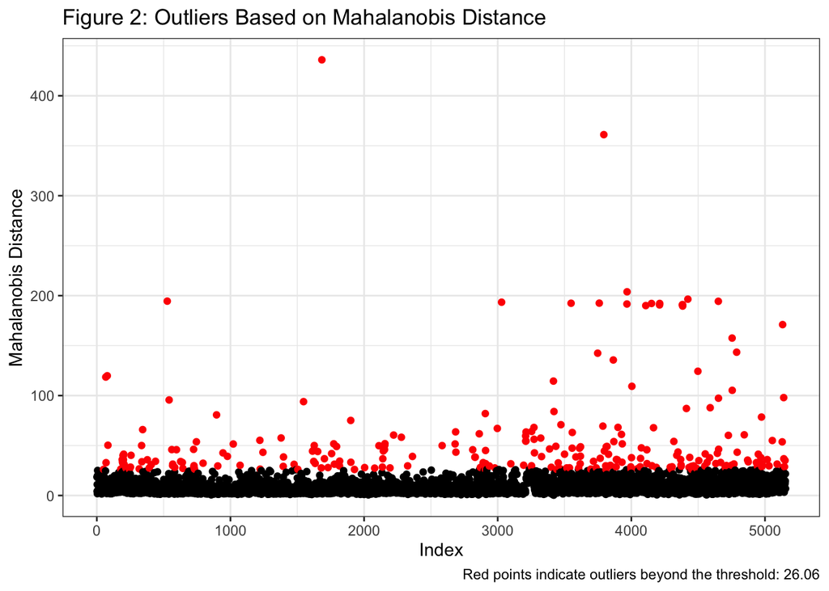

```r
# Create a data frame with Outliers_Maha and their colors based on the threshold

Outliers_Maha_df <- data.frame(
  Outliers_Maha = outliers,
  color = ifelse(outliers > Outlier_Threshold, "red", "black"))

# plot outliers based on the mahalanobis distance

ggplot(Outliers_Maha_df, aes(x = seq_along(Outliers_Maha), y = Outliers_Maha, color = color)) + geom_point(shape = 19) + scale_color_identity() +
  labs(x = "Index",
       y = "Mahalanobis Distance",
       title = "Figure 2: Outliers Based on Mahalanobis Distance",
       caption = "Red points indicate outliers beyond the threshold: 26.06") + theme_bw()
```

The analysis involved computing the Mahalanobis Distance for each observation and identifying outliers beyond the 95th percentile threshold. The threshold for outliers was determined to be 26.06, indicating that any value surpassing this threshold is classified as an outlier. These outliers were flagged and labeled accordingly, with the column `Outliers_Maha` indicating their presence. If the Mahalanobis Distance of a data point exceeded the threshold, it was marked as “1” in the `Outliers_Maha` column; otherwise, it was labeled as “0.” Figure 2 illustrates the outliers within the dataset, identified using the Mahalanobis distance, with the red data points representing those outliers.

### Local Outlier Factor (LOF)

The LOF method detects outliers by examining the local density deviation of a data point with respect to its neighbors. A data point is considered an outlier if its density significantly deviates from that of its neighbors. In this analysis, the LOF was calculated for the same set of numeric columns. Outliers were identified using a threshold value of 1.5, which indicates a substantial deviation in density compared to the surrounding data points. These outliers were flagged and labeled accordingly, with the column `Outliers_LOF` indicating their presence. If the LO) of a data point exceeded the threshold of 1.5, it was marked as “1” in the `Outliers_LOF` column; otherwise, it was labeled as “0”. Figure 3 provides a visual representation of the outliers within the dataset, with the red data points indicating those identified using the LOF algorithm.

```r
# Outlier detection using LOF
# ---------------------------

Outliers_LOF = lof(CollegeDataset2[, listofcols], minPts =  5)

# Create a colunm to identify the outliers

CollegeDataset2$Outliers_LOF = ifelse(Outliers_LOF > 1.5, 1, 0)

# print the outliers

# dim(CollegeDataset2[Outliers_LOF > 1.5, ]) # 452 outliers

# Print first 6 rows

Outlier_LOF_College2_6 <- head(CollegeDataset2)

# Present as a nice table

knitr::kable(Outlier_LOF_College2_6, caption =
               "College Dataset w/ Outliers (LOF Method)")
```

College Dataset w/ Outliers (LOF Method)

| C150_4_L4 | Completion_Rate_Median | Completion_Rate_High | NUMBRANCH | UG25ABV | HIGHDEG | UGDS | UGDS_WHITE | UGDS_BLACK | UGDS_HISP | UGDS_ASIAN | PCTPELL | PCTFLOAN | Outliers_Maha | Outliers_LOF |
| --- | --- | --- | --- | --- | --- | --- | --- | --- | --- | --- | --- | --- | --- | --- |
| 0.2807 | Below Median | Other | 1 | 0.0617 | Graduate Degree | 5098 | 0.0184 | 0.8978 | 0.0114 | 0.0014 | 0.6853 | 0.6552 | 0 | 0 |
| 0.6245 | Above Median | Other | 1 | 0.1794 | Graduate Degree | 13284 | 0.5297 | 0.2458 | 0.0669 | 0.0767 | 0.3253 | 0.4401 | 0 | 0 |
| 0.4444 | Below Median | Other | 1 | 0.8606 | Graduate Degree | 251 | 0.2470 | 0.6932 | 0.0438 | 0.0000 | 0.7852 | 0.8423 | 0 | 0 |
| 0.6072 | Above Median | Other | 1 | 0.1519 | Graduate Degree | 7358 | 0.7196 | 0.0871 | 0.0610 | 0.0357 | 0.2377 | 0.3578 | 0 | 0 |
| 0.2843 | Below Median | Other | 1 | 0.0677 | Graduate Degree | 3495 | 0.0152 | 0.9259 | 0.0129 | 0.0020 | 0.7205 | 0.7637 | 0 | 0 |
| 0.7223 | Above Median | Other | 1 | 0.0735 | Graduate Degree | 30725 | 0.7676 | 0.1050 | 0.0549 | 0.0137 | 0.1712 | 0.3454 | 0 | 0 |

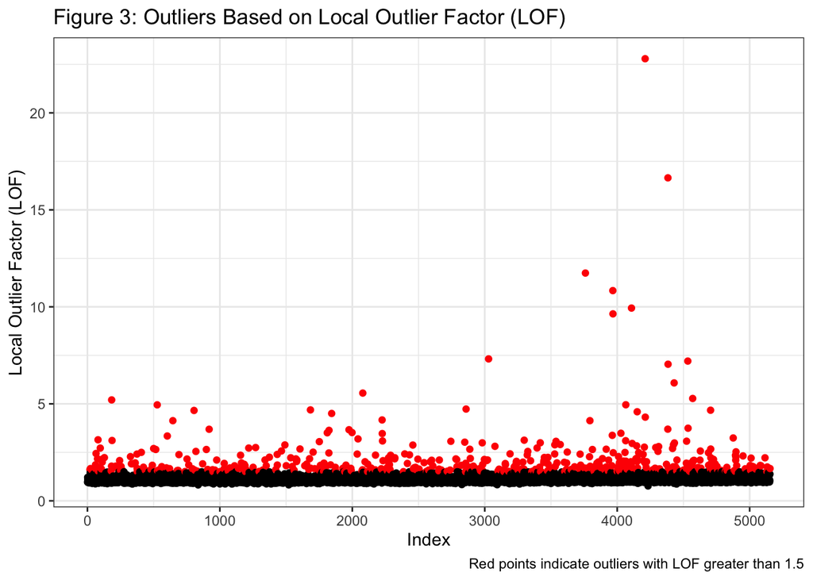

```r
# Create a data frame with outliers_lof and their colors based on the threshold

Outliers_LOF_df <- data.frame(
  LOF_Outliers = Outliers_LOF,
  color = ifelse(Outliers_LOF > 1.5, "red", "black"))

# plot outliers based on the LOF

ggplot(Outliers_LOF_df, aes(x = seq_along(Outliers_LOF), y = LOF_Outliers, color = color)) +
  geom_point(shape = 19) +
  scale_color_identity() +
  labs(x = "Index",
       y = "Local Outlier Factor (LOF)",
       title = "Figure 3: Outliers Based on Local Outlier Factor (LOF)",
       caption = "Red points indicate outliers with LOF greater than 1.5") + theme_bw()
```

### Mahalanobis Distance & LOF

To provide a comprehensive overview of outliers, the results from both the Mahalanobis Distance and LOF methods were combined. The total number of outliers was computed by summing the outliers detected by each method. Table 1 illustrates the distribution of outliers detected, with “0” indicating no outliers, “1” denoting outliers detected by either method, and “2” representing outliers identified by both Mahalanobis Distance and LOF.

```r
# Sum the two columns to get the total number of outliers

CollegeDataset2$Outliers = CollegeDataset2$Outliers_Maha + CollegeDataset2$Outliers_LOF

Outliers_Table <- table(CollegeDataset2$Outliers)

knitr::kable(Outliers_Table, caption = "Table 1:
             Summary of Outliers Detected by Mahalanobis Distance and LOF Methods")
```

Table 1: Summary of Outliers Detected by Mahalanobis Distance and LOF Methods

| Var1 | Freq |
| --- | --- |
| 0 | 4487 |
| 1 | 624 |
| 2 | 43 |

```r
# Subset data by keeping where outliers = 0 or 1
# I want to keep as much of the data to get a better quality model so thats
# why I chose to remove outliers that = 2 as both the Mahalanobis Distance and LOF
# determine there is an outlier at that specific row

CollegeDataset2 = CollegeDataset2[CollegeDataset2$Outliers %in% c(0, 1), ]

# dim(CollegeDataset2) # 5111 rows by 16 columns
```

## Multiple Linear Regression Model (Completion Rate)

A multiple linear regression (MLR) analysis was created to explore the factors impacting college completion rates. The study centered on the completion rate (`C150_4_L4`) as the response variable, with pertinent predictor variables such as the number of branches, types of degrees awarded, demographics of the student body, and financial aid statistics.

The insights presented in Table 2 provide a deeper understanding of how various factors impact college completion rates, shedding light on their magnitudes and implications within the regression model. For example:

- **Intercept (0.46)**: The intercept serves as the baseline completion rate when all predictor variables are zero. In this model, it suggests that in the absence of other factors, the expected college completion rate is approximately 46%.
- **NUMBRANCH (-0.01)**: The negative coefficient indicates that for each additional branch a college has, the completion rate decreases by approximately 0.01%. This implies that spreading resources across multiple branches might weaken support systems, hindering overall completion rates.
- **HIGHDEG Variables**:
  - **HIGHDEGCertificate Degree (0.20)**: A positive coefficient of 0.20 suggests that for each percentage point increase in the proportion of certificate degrees awarded, the completion rate increases by 0.20%. This indicates that focusing on certificate programs might positively influence completion rates.
  - **HIGHDEGAssociate Degree (-0.06)**: While the negative coefficient of -0.06 for associate degrees implies a slight decrease in completion rates with each percentage point increase in their proportion, it’s statistically insignificant, suggesting a need for further investigation into its impact.
  - **HIGHDEGBachelors Degree (-0.06)**: Similarly, the negative coefficient for bachelor’s degrees indicates a slight negative effect on completion rates, but it’s not statistically significant.
  - **HIGHDEGGraduate Degree (-0.01)**: The negligible coefficient suggests that the proportion of graduate degrees awarded doesn’t significantly influence completion rates.
- **UG25ABV (-0.06)**: With a negative coefficient, a higher percentage of undergraduates over 25 years old correlates with a decrease in completion rates by approximately 0.06%. This indicates potential challenges faced by older students in completing their degrees.
- **UGDS Variables**:
  - **UGDS_WHITE (0.07)**: The positive coefficient implies that for each percentage point increase in the proportion of White students, completion rates increase by approximately 0.07%.
  - **UGDS_BLACK (-0.11)**: Conversely, the negative coefficient suggests a decrease in completion rates by approximately 0.11% for each percentage point increase in the proportion of Black students.
  - **UGDS_HISP (0.08)**: The positive coefficient indicates that a higher proportion of Hispanic students corresponds to an increase in completion rates by approximately 0.08%.
  - **UGDS_ASIAN (0.51)**: With the highest coefficient, the presence of Asian students significantly boosts completion rates, increasing them by approximately 0.51% for each percentage point increase in their proportion.
- **PCTPELL (-0.16)**: The negative coefficient suggests that for each percentage point increase in Pell Grant recipients, completion rates decrease by approximately 0.16%. This highlights the challenges faced by economically disadvantaged students in completing their degrees.
- **PCTFLOAN (0.25)**: The positive coefficient indicates that for each percentage point increase in students with federal loans, completion rates increase by approximately 0.25%. This underscores the role of financial aid in supporting students through completion.

Therefore, the multiple linear regression model is as follows:

`C150_4_L4` = 0.46 − 0.01* `NUMBRANCH` + 0.20*`HIGHDEGCertificate Degree`− 0.06*`HIGHDEGAssociate Degree` − 0.06*`HIGHDEGBachelors Degree` − 0.01*`HIGHDEGGraduate Degree` − 0.06* `UG25ABV` + 0*`UGDS` + 0.07* `UGDS_WHITE` − 0.11*`UGDS_BLACK` + 0.08*`UGDS_HISP` + 0.51*`UGDS_ASIAN` − 0.16*`PCTPELL`+0.25*`PCTFLOAN`

```r
# Prep Work

# Subset the CollegeDataset2 to select to focus on Completion Rate

CR_Data <- CollegeDataset2 [c("NUMBRANCH",
                               "HIGHDEG",
                              "UG25ABV",
                              "UGDS",
                               "UGDS_WHITE",
                               "UGDS_BLACK",
                               "UGDS_HISP",
                               "UGDS_ASIAN",
                               "PCTPELL",
                               "PCTFLOAN",
                              "C150_4_L4")]

# ---------------------------------
# Fit the MLR model
# ---------------------------------

# Split the data into TRAIN and TEST sets

set.seed(1996)  # Set seed for reproducibility

# TRAIN

CR_Train_Index = createDataPartition(CR_Data$C150_4_L4, p = .8, list = FALSE) # 80% for training

CR_Train = CR_Data[ CR_Train_Index,]

# dim(CR_Train) 3554 rows with 11 columns

# TEST 20% for testing

CR_Test = CR_Data[-CR_Train_Index,]

# dim(CR_Test) 1520 rows with 11 columns

# ------------------------------------
# fit the model
# ------------------------------------

CR_Model = lm(C150_4_L4 ~ NUMBRANCH +
              HIGHDEG +
              UG25ABV +
              UGDS +
              UGDS_WHITE +
              UGDS_BLACK +
              UGDS_HISP +
              UGDS_ASIAN +
              PCTPELL +
              PCTFLOAN, data = CR_Train)

# summary(CR_Model)

CR_Model_Table <- tidy(CR_Model, conf.int = TRUE)

# Making a table to present the findings

nice_table(CR_Model_Table, title = "Table 2:
           Multiple Linear Regression Results of Factors Influencing College Completion Rate")
```

| Table 2: Multiple Linear Regression Results of Factors Influencing College Completion Rate Term | Table 2: Multiple Linear Regression Results of Factors Influencing College Completion Rate estimate | Table 2: Multiple Linear Regression Results of Factors Influencing College Completion Rate std.error | Table 2: Multiple Linear Regression Results of Factors Influencing College Completion Rate statistic | Table 2: Multiple Linear Regression Results of Factors Influencing College Completion Rate p | Table 2: Multiple Linear Regression Results of Factors Influencing College Completion Rate 95% CI |
| --- | --- | --- | --- | --- | --- |
| (Intercept) | 0.46 | 0.07 | 6.45 | < .001*** | [0.32, 0.60] |
| NUMBRANCH | -0.01 | 0.00 | -5.42 | < .001*** | [-0.01, -0.00] |
| HIGHDEGCertificate Degree | 0.20 | 0.07 | 3.01 | .003** | [0.07, 0.33] |
| HIGHDEGAssociate Degree | -0.06 | 0.07 | -0.95 | .344 | [-0.20, 0.07] |
| HIGHDEGBachelors Degree | -0.06 | 0.07 | -0.83 | .407 | [-0.19, 0.08] |
| HIGHDEGGraduate Degree | -0.01 | 0.07 | -0.14 | .890 | [-0.14, 0.12] |
| UG25ABV | -0.06 | 0.02 | -3.68 | < .001*** | [-0.09, -0.03] |
| UGDS | 0.00 | 0.00 | 0.52 | .600 | [-0.00, 0.00] |
| UGDS_WHITE | 0.07 | 0.02 | 2.98 | .003** | [0.02, 0.12] |
| UGDS_BLACK | -0.11 | 0.03 | -4.35 | < .001*** | [-0.17, -0.06] |
| UGDS_HISP | 0.08 | 0.03 | 2.94 | .003** | [0.03, 0.13] |
| UGDS_ASIAN | 0.51 | 0.05 | 10.12 | < .001*** | [0.41, 0.61] |
| PCTPELL | -0.16 | 0.02 | -7.89 | < .001*** | [-0.20, -0.12] |
| PCTFLOAN | 0.25 | 0.01 | 17.68 | < .001*** | [0.22, 0.28] |

```r
# Extract the Multiple R-squared and Adjusted R-squared

Multiple_R_squared <- summary(CR_Model)$r.squared

Adjusted_R_squared <- summary(CR_Model)$adj.r.squared

# Create a data frame with the extracted values

CR_RSquared_Results_Table <- data.frame(
  "Metric" = c("Multiple R-squared", "Adjusted R-squared"),
  "Value" = c(Multiple_R_squared, Adjusted_R_squared))

kable(CR_RSquared_Results_Table, caption = "Table 3:
      Multiple Linear Regression Model Performance Metrics")
```

Table 3: Multiple Linear Regression Model Performance Metrics

| Metric | Value |
| --- | --- |
| Multiple R-squared | 0.3295391 |
| Adjusted R-squared | 0.3274012 |

Furthermore, Table 3 provides the performance metrics of the multiple linear regression model used to analyze the factors affecting college completion rates. Two key metrics are presented: the Multiple R-squared and Adjusted R-squared values.

The Multiple R-squared (R^2) value, also known as the coefficient of determination, indicates the proportion of the variance in college completion rates explained by the predictor variables included in the model. With a value of approximately 0.33, it suggests that around 33% of the variability in completion rates can be attributed to the variables considered in the regression model. A higher R-squared value suggests a better fit of the model to the data, signifying stronger explanatory power collectively from the predictor variables.

The Adjusted R-squared value, approximately 0.33 in this case, adjusts for the number of predictor variables in the model. It penalizes the inclusion of unnecessary variables that do not significantly enhance the model’s explanatory ability. Despite being slightly lower than the Multiple R-squared, the Adjusted R-squared value provides a more accurate assessment of the model’s goodness-of-fit, considering the model’s complexity.

From these metrics, it can be inferred that the regression model, while statistically significant with a moderate R-squared value, only explains a portion of the variability in college completion rates. This implies the presence of other unaccounted factors influencing completion rates. Additionally, the robustness of the model’s fit, as indicated by the Adjusted R-squared value, remains intact even after accounting for the number of predictor variables included in the analysis.

### Ridge Regression

In the exploration of the multiple linear regression model, ridge regression is applied to further analyze the factors influencing college completion rates. Ridge regression introduces regularization to the model, aiming to mitigate multicollinearity and overfitting by adding a penalty term to the coefficient estimates.

In employing ridge regression with an alpha value of 0, the process involves determining the optimal lambda value through cross-validation. This lambda value serves as the regularization parameter, crucial for minimizing the mean squared error of the model. Specifically, two important lambda values are calculated: `lambda.min` and `lambda.1se`.

`Lambda.min` represents the value of lambda that minimizes the mean squared error, ensuring the best possible fit to the data. It prioritizes prediction accuracy, potentially resulting in more complex models.

`Lambda.1se`, on the other hand, is the largest lambda value within one standard error of `lambda.min`. It provides a more conservative approach, favoring simpler models that are less susceptible to overfitting while maintaining reasonable predictive accuracy.

```r
# ------------------------------------
# Now apply regularization to the model
# ------------------------------------

# -------------------------------------
# Apply Ridge
# alpha = 0 for Ridge
# Use Cv.glmnet to find the best lambda
#---------------------------------------

CR_Model_Ridge_CV = cv.glmnet(as.matrix(CR_Train[, -ncol(CR_Train)]),
                              CR_Train$C150_4_L4, alpha = 0)

# print the best lambda

# CR_Model_Ridge_CV$lambda.min # lambda.min = 0.005179007

# Print coefficients for the best lambda

CR_Coefficients_Ridge <- predict(CR_Model_Ridge_CV, s = "lambda.min", type = "coefficients")

# Convert the sparse matrix to a regular matrix

CR_Coefficients_Ridge_matrix <- as.matrix(CR_Coefficients_Ridge)

# Convert the matrix to a data frame
# Convert coefficients to a data frame

CR_Coefficients_Ridge_df <- as.data.frame(CR_Coefficients_Ridge_matrix)

# Create a basic table using kable

kable(CR_Coefficients_Ridge_df, caption = "Table 4: Ridge Regression Coefficients
      Analyzing Factors Influencing College Completion Rate")
```

Table 4: Ridge Regression Coefficients Analyzing Factors Influencing College Completion Rate

|  | lambda.min |
| --- | --- |
| (Intercept) | 0.3707355 |
| NUMBRANCH | -0.0074852 |
| HIGHDEG | 0.0000000 |
| UG25ABV | 0.0497032 |
| UGDS | -0.0000035 |
| UGDS_WHITE | 0.1537852 |
| UGDS_BLACK | -0.0315805 |
| UGDS_HISP | 0.1548810 |
| UGDS_ASIAN | 0.5598989 |
| PCTPELL | -0.0761827 |
| PCTFLOAN | 0.2576537 |

```r
# print the best lambda.1se

# CR_Model_Ridge_CV$lambda.1se # lambda.1se = 0.05300874

# Print coefficients for the best lambda.1se

CR_Coefficients_Ridge_Lambda1se <- predict(CR_Model_Ridge_CV, s = "lambda.1se", type = "coefficients")

# Convert the sparse matrix to a regular matrix

CR_Coefficients_Ridge_Lambda1se_matrix <- as.matrix(CR_Coefficients_Ridge_Lambda1se)

# Convert the matrix to a data frame
# Convert coefficients to a data frame

CR_Coefficients_Ridge_Lambda1se_df <- as.data.frame(CR_Coefficients_Ridge_Lambda1se_matrix)

# Create a basic table using kable

# kable(CR_Coefficients_Ridge_df, caption = "Table 4B: Ridge Regression Coefficients
      # Analyzing Factors Influencing College Completion Rate")

### Either lambda.min or lambda.1se result in the same coefficients although they result in different values.
```

In Table 4, the results of the ridge regression analysis are presented, detailing the coefficients of predictor variables influencing college completion rates. The analysis reveals valuable insights into the magnitude and direction of these relationships. For example:

- **Intercept (0.3707355)**: Serving as the baseline, this coefficient represents the estimated completion rate when all predictor variables are zero. It provides context for interpreting the effects of other variables.
- **NUMBRANCH (-0.0074852)**: The negative coefficient suggests that an increase in the number of branches is associated with a slight decrease in completion rates. This implies that institutions with more branches may face challenges in achieving higher completion rates, possibly due to logistical or administrative complexities.
- **HIGHDEG (0)**: With a coefficient close to zero, the types of degrees awarded by the college have a negligible influence on completion rates, according to this analysis. This suggests that regardless of the degree types offered (certificate, associate, bachelor, or master’s), their impact on completion rates is minimal.
- **UG25ABV (0.0497032)**: A positive coefficient indicates that a higher percentage of undergraduate students over 25 years old correlates with a modest increase in completion rates. This suggests that institutions with a significant proportion of older undergraduate students may have higher completion rates, possibly due to their greater maturity and dedication to completing their studies.
- **UGDS (-0.0000035)**: The coefficient close to zero suggests that total undergraduate enrollment has minimal impact on completion rates. This implies that the sheer size of the student body does not significantly affect completion rates, highlighting the need to focus on other factors to improve outcomes.
- **Demographic Composition**:
  - **UGDS_WHITE (0.1537852)**: A positive coefficient indicates that a higher percentage of White students is associated with higher completion rates. This underscores the importance of diversity and inclusion efforts in fostering positive educational outcomes for all student demographics.
  - **UGDS_BLACK (-0.0315805)**: The negative coefficient suggests that a higher percentage of Black students correlates with lower completion rates. Addressing equity gaps and providing tailored support to underrepresented minority groups may be essential in improving completion rates for these students.
  - **UGDS_HISP (0.1548810)**: The positive coefficient indicates that a higher percentage of Hispanic students is associated with higher completion rates. This highlights the importance of culturally responsive practices and targeted interventions to support Hispanic student success.
  - **UGDS_ASIAN (0.5598989)**: Among demographic variables, a higher percentage of Asian students exhibits the strongest positive impact on completion rates, correlating with significantly higher completion rates. Understanding and replicating the factors contributing to the success of Asian students may inform strategies to enhance completion rates for all students.
- **Financial Aid Metrics**:
  - **PCTPELL (-0.0761827)**: The negative coefficient suggests that a higher percentage of Pell Grant recipients correlates with lower completion rates. This underscores the challenges faced by economically disadvantaged students and the importance of addressing barriers to their success.
  - **PCTFLOAN (0.2576537)**: The positive coefficient indicates that a higher percentage of students with federal loans is associated with higher completion rates. This suggests that access to financial aid, particularly in the form of federal loans, may facilitate degree completion for some students.

Therefore, the ridge regression model is as follows:

Predicted (`C150_4_L4`) = 0.3707355 + (-0.0074852) * `NUMBRANCH` + (0.0000000) * `HIGHDEG` + (0.0497032) * `UG25ABV` + (-0.0000035) * `UGDS` + (0.1537852) * `UGDS_WHITE` + (-0.0315805) * `UGDS_BLACK` + (0.1548810) * `UGDS_HISP` + (0.5598989) * `UGDS_ASIAN` + (-0.0761827) * `PCTPELL` + (0.2576537) * `PCTFLOAN`

Overall, ridge regression enhances the understanding of the relationships between predictor variables and college completion rates by incorporating regularization techniques. The resulting coefficients offer valuable insights for decision-makers in academia to identify and address factors affecting completion rates effectively.

#### Train Data

- **4A:** The Ridge Regression R^2 value obtained using the `lambda.min` parameter was found to be 0.1240899. This indicates that approximately 12.41% of the variability in college completion rates can be explained by the predictor variables included in the model. This suggests that the model captures a modest portion of the variation in completion rates, providing valuable insight into factors influencing student success.

```r
# make predictions (lambda.min)

CR_Predictions_Ridge_CV_Train = predict(CR_Model_Ridge_CV, newx = as.matrix(CR_Train[, -ncol(CR_Train)]),s = "lambda.min")

# Calculate R2

CR_R2_Ridge_CV_Train = 1 - (sum((CR_Train$C150_4_L4 - CR_Predictions_Ridge_CV_Train)^2) / sum((CR_Train$C150_4_L4 - mean(CR_Train$C150_4_L4))^2))

kable(CR_R2_Ridge_CV_Train, caption = "4A: Ridge Regression R-squared for College Completion Rate Prediction (lambda.min)")
```

4A: Ridge Regression R-squared for College Completion Rate Prediction (lambda.min)

| x |
| --- |
| 0.1240899 |

```r
# make predictions (lambda.1se)

CR_Predictions_Ridge_CV_Train_Lambda1se = predict(CR_Model_Ridge_CV, newx = as.matrix(CR_Train[, -ncol(CR_Train)]),s = "lambda.1se")

# Calculate R2

CR_R2_Ridge_CV_Train_Lambda1se = 1 - (sum((CR_Train$C150_4_L4 - CR_Predictions_Ridge_CV_Train_Lambda1se)^2) / sum((CR_Train$C150_4_L4 - mean(CR_Train$C150_4_L4))^2))

kable(CR_R2_Ridge_CV_Train_Lambda1se, caption = "4B: Ridge Regression R-squared for College Completion Rate Prediction (lambda.1se)")
```

4B: Ridge Regression R-squared for College Completion Rate Prediction (lambda.1se)

| x |
| --- |
| 0.1138844 |

```r
## Write another paragraph with the other lambda result and stat how although the coefficients don't change the r square value do and most likely so will the matrix in the LR down below.
```

- **4B:** Similarly, the Ridge Regression R^2 value computed using the `lambda.1se` parameter was 0.1138844. This suggests that approximately 11.39% of the variability in college completion rates can be explained by the model. While slightly lower than the R^2 value obtained with `lambda.min`, it still signifies a meaningful level of explanatory power.

These findings offer valuable insights into the effectiveness of the ridge regression model in predicting college completion rates. While neither R^2 value is particularly high, they indicate that the model captures a portion of the variability in completion rates. This information can guide strategic decision-making processes within educational institutions, helping to identify areas for improvement and interventions to enhance student outcomes.

#### Test Data

- **4C:** The Ridge Regression R^2 value obtained for the test data, using the `lambda.min` parameter, was found to be 0.1417864. This indicates that approximately 14.18% of the variability in college completion rates can be explained by the predictor variables included in the model. This suggests that the model demonstrates a moderate ability to predict college completion rates based on the test data.

```r
# make predictions (lambda.min)

CR_Predictions_Ridge_CV_Test = predict(CR_Model_Ridge_CV, newx = as.matrix(CR_Test[, -ncol(CR_Test)]), s = "lambda.min")

# Calculate R2

CR_R2_Ridge_CV_Test = 1 - (sum((CR_Test$C150_4_L4 - CR_Predictions_Ridge_CV_Test)^2) / sum((CR_Test$C150_4_L4 - mean(CR_Test$C150_4_L4))^2))

kable(CR_R2_Ridge_CV_Test, caption = "4C: Ridge Regression R-squared for College Completion Rate Prediction (Test Data)")
```

4C: Ridge Regression R-squared for College Completion Rate Prediction (Test Data)

| x |
| --- |
| 0.1417864 |

```r
# make predictions (lambda.1se)

CR_Predictions_Ridge_CV_Test_Lambda1se = predict(CR_Model_Ridge_CV, newx = as.matrix(CR_Train[, -ncol(CR_Train)]),s = "lambda.1se")

# Calculate R2

CR_R2_Ridge_CV_Test_Lambda1se = 1 - (sum((CR_Train$C150_4_L4 - CR_Predictions_Ridge_CV_Test_Lambda1se)^2) / sum((CR_Train$C150_4_L4 - mean(CR_Train$C150_4_L4))^2))

kable(CR_R2_Ridge_CV_Train_Lambda1se, caption = "4D: Ridge Regression R-squared for College Completion Rate Prediction (lambda.1se)")
```

4D: Ridge Regression R-squared for College Completion Rate Prediction (lambda.1se)

| x |
| --- |
| 0.1138844 |

These findings provide valuable insights into the effectiveness of the ridge regression model in predicting college completion rates when applied to unseen test data. The higher R^2 value obtained with `lambda.min` suggests that the model performs relatively well in explaining the variability in completion rates. However, it’s important to note that the model’s performance may vary depending on the choice of regularization parameter. These insights can inform decision-making processes within educational institutions, aiding in the development of strategies to support student success and improve completion rates.

### LASSO

In this section, the application of LASSO (Least Absolute Shrinkage and Selection Operator) regression is detailed. LASSO is employed to identify the most significant predictors of college completion rates while simultaneously performing variable selection.

The analysis begins with fitting the LASSO model to the training data. By setting the alpha parameter to 1, LASSO regularization is applied, favoring sparse models where some coefficients are reduced to exactly zero. Through cross-validation, the optimal lambda value is determined to strike a balance between minimizing prediction error and preventing overfitting. In this analysis, both the `lambda.min` value (0.0003104733) and the `lambda.1se` value (0.007341109) are calculated, reflecting different levels of regularization. Table 5A and 5B will respectively present the LASSO model based on each lambda value, providing insights into the selected predictors and their coefficients.

Table 5A (`lambda.min`) presents the coefficients resulting from the LASSO regression analysis, which aims to identify the most significant predictors of college completion rates. Starting with the intercept (0.3504087), this coefficient represents the completion rate when all predictor variables are zero. In this context, it serves as a baseline for comparison.

Moving on to the predictor variables:

- **NUMBRANCH (-0.0074946):** This negative coefficient suggests that an increase in the number of branches corresponds to a slight reduction in completion rates. While the effect is relatively minor, it highlights the potential challenges associated with managing multiple branches and the importance of strategic planning in mitigating any adverse impact on completion rates.
- **HIGHDEG (0):** With a coefficient of zero, the types of degrees awarded by the college do not significantly influence completion rates in the LASSO model. This implies that the distribution of degrees among students does not play a substantial role in determining completion rates.
- **UG25ABV (0.0494927):** The positive coefficient indicates that a higher percentage of undergraduate students over 25 years old is associated with a slight increase in completion rates. This suggests that older students may possess greater determination or commitment to completing their studies, contributing positively to overall completion rates.
- **UGDS (-0.0000036):** The coefficient’s proximity to zero implies that total undergraduate enrollment has minimal impact on completion rates. While enrollment size is an important consideration for educational institutions, the model suggests that it may not significantly affect completion rates.
- **Demographic Composition:**
  - **UGDS_WHITE (0.1754200):** This positive coefficient suggests that a higher percentage of White students positively influences completion rates. It implies that colleges with a larger proportion of White students tend to exhibit higher completion rates, possibly due to various socio-economic factors or institutional support mechanisms tailored to this demographic.
  - **UGDS_BLACK (-0.0105645):** Conversely, the negative coefficient indicates that a higher percentage of Black students is associated with lower completion rates. This underscores the importance of addressing disparities in educational outcomes and implementing targeted interventions to support Black students and enhance their chances of completing their academic programs.
  - **UGDS_HISP (0.1787894):** The positive coefficient suggests that a higher percentage of Hispanic students positively impacts completion rates. Educational institutions with a significant Hispanic student population may benefit from cultural competency initiatives and support services tailored to the needs of Hispanic students to improve their retention and completion rates.
  - **UGDS_ASIAN (0.5943168):** With the highest coefficient among demographic variables, a higher percentage of Asian students significantly boosts completion rates. This indicates that colleges with a substantial Asian student population tend to have higher completion rates, possibly due to cultural factors, academic preparedness, or other institutional characteristics that facilitate student success.
- **Financial Aid Metrics:**
  - **PCTPELL (-0.0817687):** The negative coefficient suggests that a higher percentage of Pell Grant recipients is associated with lower completion rates. This highlights the challenges faced by students from low-income backgrounds and underscores the importance of financial aid policies and support programs in promoting student success and retention.
  - **PCTFLOAN (0.2646317):** The positive coefficient indicates that a higher percentage of students with federal loans correlates with higher completion rates. This suggests that access to federal loans may enable students to overcome financial barriers and complete their academic programs successfully.

Therefore, the LASSO regression model with the coefficients at `lambda.min` is as follows:

Predicted (`C150_4_L4`) = 0.3504087 + (-0.0074946) * `NUMBRANCH` + 0.0494927 * `UG25ABV` + (-0.0000036) * `UGDS` + 0.1754200 * `UGDS_WHITE` + (-0.0105645) * `UGDS_BLACK` + 0.1787894 * `UGDS_HISP` + 0.5943168 * `UGDS_ASIAN` + (-0.0817687) * `PCTPELL` + 0.2646317 * `PCTFLOAN`

```r
# ------------------------------------
# Apply Lasso and Fit the model
# alpha = 1 for Lasso
# Use Cv.glmnet to find the best lambda
# ------------------------------------

# Creating Model

CR_Model_Lasso_CV = cv.glmnet(as.matrix(CR_Train[, -ncol(CR_Train)]), CR_Train$C150_4_L4, alpha = 1)

# print the best lambda (lambda.min)

# CR_Model_Lasso_CV$lambda.min # lambda.min = 0.0003104733

# Print coefficients for the best lambda

CR_Coefficients_LASSO <- predict(CR_Model_Lasso_CV, s = "lambda.min", type = "coefficients")

# Convert the sparse matrix to a regular matrix

CR_Coefficients_LASSO_Matrix <- as.matrix(CR_Coefficients_LASSO)

# Convert the matrix to a data frame
# Convert coefficients to a data frame

CR_Coefficients_LASSO_df <- as.data.frame(CR_Coefficients_LASSO_Matrix)

# Create a basic table using kable

kable(CR_Coefficients_LASSO_df, caption = "Table 5A: LASSO Regression Coefficients
      Analyzing Factors Influencing College Completion Rate")
```

Table 5A: LASSO Regression Coefficients Analyzing Factors Influencing College Completion Rate

|  | lambda.min |
| --- | --- |
| (Intercept) | 0.3504087 |
| NUMBRANCH | -0.0074946 |
| HIGHDEG | 0.0000000 |
| UG25ABV | 0.0494927 |
| UGDS | -0.0000036 |
| UGDS_WHITE | 0.1754200 |
| UGDS_BLACK | -0.0105645 |
| UGDS_HISP | 0.1787894 |
| UGDS_ASIAN | 0.5943168 |
| PCTPELL | -0.0817687 |
| PCTFLOAN | 0.2646317 |

```r
# print the best lambda (lambda.1se)

# CR_Model_Lasso_CV$lambda.1se # lambda.1se =  0.007341109

# Print coefficients for the best lambda (lambda.1se)

CR_Coefficients_LASSO_Lambda1se <- predict(CR_Model_Lasso_CV, s = "lambda.1se", type = "coefficients")

# Convert the sparse matrix to a regular matrix

CR_Coefficients_LASSO_Lambda1se_Matrix <- as.matrix(CR_Coefficients_LASSO_Lambda1se)

# Convert the matrix to a data frame
# Convert coefficients to a data frame

CR_Coefficients_LASSO_Lambda1se_df <- as.data.frame(CR_Coefficients_LASSO_Lambda1se_Matrix)

# Create a basic table using kable

kable(CR_Coefficients_LASSO_Lambda1se_df, caption = "Table 5B: LASSO Regression Coefficients
      Analyzing Factors Influencing College Completion Rate")
```

Table 5B: LASSO Regression Coefficients Analyzing Factors Influencing College Completion Rate

|  | lambda.1se |
| --- | --- |
| (Intercept) | 0.4853050 |
| NUMBRANCH | -0.0048453 |
| HIGHDEG | 0.0000000 |
| UG25ABV | 0.0000000 |
| UGDS | -0.0000021 |
| UGDS_WHITE | 0.0235416 |
| UGDS_BLACK | -0.1174150 |
| UGDS_HISP | 0.0000000 |
| UGDS_ASIAN | 0.3369200 |
| PCTPELL | 0.0000000 |
| PCTFLOAN | 0.2025453 |

Table 5B (lambda.1se) displays the coefficients derived from the LASSO regression analysis, aimed at identifying significant predictors of college completion rates.

Intercept (0.4853050): This intercept represents the baseline completion rate when all predictor variables are zero, providing a reference point for comparison.

Predictor Variables:

- **NUMBRANCH (-0.0048453):** The negative coefficient suggests that an increase in the number of branches is associated with a slight decrease in completion rates. While the effect is minimal, it highlights the importance of strategic planning in managing multiple branches to mitigate any adverse impact on completion rates.
- **HIGHDEG (0):** With a coefficient of zero, the types of degrees awarded by the college do not significantly influence completion rates in the LASSO model.
- **UG25ABV (0):** The coefficient’s proximity to zero indicates that the percentage of undergraduate students over 25 years old has minimal impact on completion rates.
- **UGDS (-0.0000021):** The coefficient suggests that total undergraduate enrollment has negligible impact on completion rates.
- **Demographic Composition:**
  - **UGDS_WHITE (0.0235416):** A positive coefficient implies that a higher percentage of White students positively influences completion rates, possibly due to socio-economic factors or institutional support mechanisms tailored to this demographic.
  - **UGDS_BLACK (-0.1174150):** Conversely, the negative coefficient indicates that a higher percentage of Black students is associated with lower completion rates, highlighting the importance of addressing disparities in educational outcomes.
  - **UGDS_HISP (0):** With a coefficient of zero, the percentage of Hispanic students does not significantly impact completion rates in the LASSO model.
  - **UGDS_ASIAN (0.3369200):** The positive coefficient indicates that a higher percentage of Asian students significantly boosts completion rates, suggesting cultural factors or institutional characteristics that facilitate student success.
- **Financial Aid Metrics:**
  - **PCTPELL (0):** The coefficient’s proximity to zero suggests that the percentage of Pell Grant recipients has minimal impact on completion rates.
  - **PCTFLOAN (0.2025453):** A positive coefficient implies that a higher percentage of students with federal loans correlates with higher completion rates, indicating the role of federal loans in overcoming financial barriers to academic completion.

Therefore, the LASSO regression model with the coefficients at `lambda.1se` is as follows:

Predicted (`C150_4_L4`) = 0.4853050 -0.0048453 * `NUMBRANCH` - 0.0000021 * `UGDS` + 0.0235416 * `UGDS_WHITE` - 0.1174150 * `UGDS_BLACK` + 0.3369200 * `UGDS_ASIAN` + 0.2025453 * `PCTFLOAN`

These findings provide valuable insights into the complex interplay of factors influencing college completion rates and can inform strategic decision-making and policy development aimed at enhancing student success and retention in higher education institutions.

#### Train Data

```r
# make predictions (lambda.min)

CR_Predictions_Lasso_CV_Train = predict(CR_Model_Lasso_CV, newx = as.matrix(CR_Train[, -ncol(CR_Train)]), s = "lambda.min")

# Calculate R2

CR_R2_Lasso_CV_Train = 1 - (sum((CR_Train$C150_4_L4 - CR_Predictions_Lasso_CV_Train)^2) / sum((CR_Train$C150_4_L4 - mean(CR_Train$C150_4_L4))^2))

kable(CR_R2_Lasso_CV_Train, caption = "5C: LASSO Regression R-squared for College Completion Rate Prediction (lambda.min)")
```

5C: LASSO Regression R-squared for College Completion Rate Prediction (lambda.min)

| x |
| --- |
| 0.1244594 |

```r
# make predictions (lambda.1se)

CR_Predictions_Lasso_CV_Train_Lambda1se = predict(CR_Model_Lasso_CV, newx = as.matrix(CR_Train[, -ncol(CR_Train)]), s = "lambda.1se")

# Calculate R2

CR_R2_Lasso_CV_Train_Lambda1se = 1 - (sum((CR_Train$C150_4_L4 - CR_Predictions_Lasso_CV_Train_Lambda1se)^2) / sum((CR_Train$C150_4_L4 - mean(CR_Train$C150_4_L4))^2))

kable(CR_R2_Lasso_CV_Train_Lambda1se, caption = "5D: LASSO Regression R-squared for College Completion Rate Prediction (lambda.1se)")
```

5D: LASSO Regression R-squared for College Completion Rate Prediction (lambda.1se)

| x |
| --- |
| 0.1056068 |

Similarly, utilizing the `lambda.1se` (5D) parameter resulted in an R-squared value of 0.1056068. These findings suggest that while the LASSO model demonstrates some predictive ability, it explains only a modest portion of the variance in college completion rates. This implies that factors beyond those included in the current model may also influence completion rates and should be considered for a more comprehensive understanding. Further refinement of the model or exploration of additional predictors may be necessary to improve its predictive accuracy and capture a more substantial portion of the variability in completion rates.

#### Test Data

In assessing the test data, the LASSO regression analysis revealed notable insights into the predictive performance of the model. When using the `lambda.min` parameter, the model achieved an R^2 value of 0.1435921. This indicates that approximately 14.36% of the variability in college completion rate prediction can be explained by the predictor variables included in the model.

```r
# make predictions (lambda.min)

CR_Predictions_Lasso_CV_Test = predict(CR_Model_Lasso_CV, newx = as.matrix(CR_Test[, -ncol(CR_Test)]), s = "lambda.min")

# Calculate R2

CR_R2_Lasso_CV_Test = 1 - (sum((CR_Test$C150_4_L4 - CR_Predictions_Lasso_CV_Test)^2) / sum((CR_Test$C150_4_L4 - mean(CR_Test$C150_4_L4))^2))

kable(CR_R2_Lasso_CV_Test, caption = "5E: LASSO Regression R-squared for College Completion Rate Prediction (Test Data)")
```

5E: LASSO Regression R-squared for College Completion Rate Prediction (Test Data)

| x |
| --- |
| 0.1435921 |

```r
# make predictions (lambda.1se)

CR_Predictions_Lasso_CV_Test_Lambda1se = predict(CR_Model_Lasso_CV, newx = as.matrix(CR_Test[, -ncol(CR_Test)]), s = "lambda.1se")

# Calculate R2

CR_R2_Lasso_CV_Test_Lambda1se = 1 - (sum((CR_Test$C150_4_L4 - CR_Predictions_Lasso_CV_Test_Lambda1se)^2) / sum((CR_Test$C150_4_L4 - mean(CR_Test$C150_4_L4))^2))

kable(CR_R2_Lasso_CV_Test_Lambda1se, caption = "5F: LASSO Regression R-squared for College Completion Rate Prediction (Test Data)")
```

5F: LASSO Regression R-squared for College Completion Rate Prediction (Test Data)

| x |
| --- |
| 0.1083415 |

Similarly, employing the `lambda.1se` parameter resulted in an R^2 value of 0.1083415. These findings suggest that the LASSO model demonstrates some predictive ability on the test data but explains a modest portion of the variance in college completion rates. While the model exhibits a slightly higher R^2 value compared to the training data, indicating better performance on the test set, it still suggests that additional factors beyond those considered in the current model may influence completion rates. Therefore, further refinement or exploration of additional predictors may be necessary to enhance the model’s predictive accuracy and capture a more substantial portion of the variability in completion rates.

## Logistic Regression Model (Completion Rate Medium)

As previously noted in another analysis, the choice of “Completion Rate Medium” as the response variable is based on its balanced nature. This term refers to the scenario where the classes within a response variable are distributed relatively evenly, ensuring that neither class dominates the other in terms of frequency. In the case of “Completion Rate Medium,” the dataset displays a near-equal distribution between its categories. Specifically, there are 2,534 instances classified as “below median” (0) and 2,577 (1) instances classified as “above median.” This balance ensures that predictive models developed using this response variable don’t favor any particular outcome, leading to a more robust and unbiased analysis.

The frequency table provided in Table 6 represents this observation, demonstrating a nearly equivalent number of instances in each category, further validating the balanced nature of the response variable. This balance enhances the reliability of predictive models built on this variable, ensuring that they accurately represent the underlying data distribution and can provide actionable insights without being skewed towards any specific outcome.

A logistic regression analysis was conducted to investigate the factors influencing college completion rate medium (`Completion_Rate_Median`). The study focused on `Completion_Rate_Median` as the response variable, with various predictor variables including the number of branches, types of degrees awarded, demographics of the student body, and financial aid statistics. The insights from Table 7 provide valuable insights into the factors influencing college completion rates and their respective magnitudes within the regression model:

- **Intercept (-0.75):** The intercept signifies the baseline completion rate when all predictor variables are zero. In this model, it indicates an estimated completion rate of -0.75%. However, it’s not statistically significant (p = 0.454).
- **NUMBRANCH (-0.03):** For each additional branch, completion rates decrease by approximately 0.03%. This suggests that spreading resources across multiple branches might weaken support systems, hindering overall completion rates (p = 0.023*).
- **HIGHDEG Variables:**
  - **HIGHDEGCertificate Degree (2.14):** A positive coefficient of 2.14 indicates that for each percentage point increase in the proportion of certificate degrees awarded, completion rates increase by approximately 2.14% (p = 0.023).
  - **HIGHDEGAssociate Degree (-0.60):** While the negative coefficient of -0.60 for associate degrees implies a decrease in completion rates, it’s not statistically significant (p = 0.524).
  - **HIGHDEGBachelors Degree (-0.51):** Similarly, the negative coefficient suggests a decrease in completion rates for bachelor’s degrees, but it’s not statistically significant (p = 0.592).
  - **HIGHDEGGraduate Degree (-0.21):** The insignificant coefficient indicates that the proportion of graduate degrees awarded doesn’t significantly influence completion rates (p = 0.822).
- **UG25ABV (-0.36):** A negative coefficient suggests that a higher percentage of undergraduates over 25 years old correlates with a decrease in completion rates by approximately 0.36%, though not statistically significant (p = 0.070).
- **UGDS Variables:**
  - **UGDS_WHITE (0.29):** For each percentage point increase in the proportion of White students, completion rates increase by approximately 0.29%, though not statistically significant (p = 0.384).
  - **UGDS_BLACK (-1.84):** Conversely, the negative coefficient suggests a decrease in completion rates by approximately 1.84% for each percentage point increase in the proportion of Black students, which is statistically significant (p < 0.001).
  - **UGDS_HISP (0.57):** A positive coefficient indicates that a higher proportion of Hispanic students corresponds to an increase in completion rates by approximately 0.57%, though not statistically significant (p = 0.096).
  - **UGDS_ASIAN (5.51):** With the highest coefficient, the presence of Asian students significantly boosts completion rates, increasing them by approximately 5.51% for each percentage point increase in their proportion, which is statistically significant (p < 0.001).
- **PCTPELL (-2.03):** For each percentage point increase in Pell Grant recipients, completion rates decrease by approximately 2.03%, significantly impacting economically disadvantaged students (p < 0.001).
- **PCTFLOAN (2.94):** Conversely, for each percentage point increase in students with federal loans, completion rates increase by approximately 2.94%, emphasizing the role of financial aid in supporting completion (p < 0.001).

Therefore, the logistic regression model is as follows:

logit (P (Y = `Completion Rate Medium`)) = − 0.75 − 0.03*`NUMBRANCH` + 2.14*`HIGHDEG_Certificate_Degree` − 0.60*`HIGHDEG_Associate_Degree` − 0.51*`HIGHDEG_Bachelors_Degree` − 0.21*`HIGHDEG_Graduate_Degree` − 0.36*`UG25ABV` + 0.00*`UGDS` + 0.29*`UGDS_WHITE` − 1.84*`UGDS_BLACK` + 0.57*`UGDS_HISP` + 5.51*`UGDS_ASIAN` − 2.03*`PCTPELL` + 2.94*`PCTFLOAN`

```r
# Prep Work

# Subset the CollegeDataset2 to select to focus on "Completion_Rate_Median"

CRM_Data <- CollegeDataset2 [c("NUMBRANCH",
                               "HIGHDEG",
                               "UG25ABV",
                               "UGDS",
                               "UGDS_WHITE",
                               "UGDS_BLACK",
                               "UGDS_HISP",
                               "UGDS_ASIAN",
                               "PCTPELL",
                               "PCTFLOAN",
                               "Completion_Rate_Median")]

# ----------------------------------------------------
# Convert y (Completion_Rate_Median) values to 0 and 1
# ----------------------------------------------------

CRM_Data$Completion_Rate_Median <- ifelse(CRM_Data$Completion_Rate_Median
                                           == "Above Median", 1, 0)

CRM_Freq_Table <- table(CRM_Data$Completion_Rate_Median)

knitr::kable(CRM_Freq_Table, caption = "Table 6:
            Frequency Table of Completion Rate Median")
```

Table 6: Frequency Table of Completion Rate Median

| Var1 | Freq |
| --- | --- |
| 0 | 2534 |
| 1 | 2577 |

```r
# ---------------------------------
# Fit the logistic regression model
# ---------------------------------

# Split the data into TRAIN sets

set.seed(1996)  # Set seed for reproducibility

# TRAIN

CRM_Train_Indices <- sample(nrow(CRM_Data), nrow(CRM_Data) * 0.8) # 80% for training

CRM_Train_Data <- CRM_Data[CRM_Train_Indices, ]

# dim(CRM_Train_Data) 4059 rows with 12 columns

# TEST

CRM_Test_Data <- CRM_Data[-CRM_Train_Indices, ] # 20% for testing

# dim(CRM_Test_Data) 1015 rows with 12 columns

# Fit the logistic regression model on the CRM_Train_Data

CRM_Model <- glm(Completion_Rate_Median ~ NUMBRANCH + HIGHDEG + UG25ABV +
                 UGDS + UGDS_WHITE + UGDS_BLACK + UGDS_HISP + UGDS_ASIAN +
                 PCTPELL + PCTFLOAN, data = CRM_Train_Data, family = binomial)

# summary(CRM_Model) ##### USE TRAIN MODEL!!!

# Presenting findings in table format

CRM_Model_Table <- tidy(CRM_Model, conf.int = TRUE)

nice_table(CRM_Model_Table, title = "Table 7:
Logistic Regression Analysis of Factors Influencing College Completion Rate Medium")
```

| Table 7: Logistic Regression Analysis of Factors Influencing College Completion Rate Medium Term | Table 7: Logistic Regression Analysis of Factors Influencing College Completion Rate Medium estimate | Table 7: Logistic Regression Analysis of Factors Influencing College Completion Rate Medium std.error | Table 7: Logistic Regression Analysis of Factors Influencing College Completion Rate Medium statistic | Table 7: Logistic Regression Analysis of Factors Influencing College Completion Rate Medium p | Table 7: Logistic Regression Analysis of Factors Influencing College Completion Rate Medium 95% CI |
| --- | --- | --- | --- | --- | --- |
| (Intercept) | -0.75 | 1.00 | -0.75 | .454 | [-2.94, 1.12] |
| NUMBRANCH | -0.03 | 0.02 | -2.28 | .023* | [-0.06, -0.01] |
| HIGHDEGCertificate Degree | 2.14 | 0.94 | 2.27 | .023* | [0.39, 4.25] |
| HIGHDEGAssociate Degree | -0.60 | 0.94 | -0.64 | .524 | [-2.36, 1.51] |
| HIGHDEGBachelors Degree | -0.51 | 0.95 | -0.54 | .592 | [-2.28, 1.61] |
| HIGHDEGGraduate Degree | -0.21 | 0.95 | -0.22 | .822 | [-1.98, 1.90] |
| UG25ABV | -0.36 | 0.20 | -1.81 | .070 | [-0.76, 0.03] |
| UGDS | 0.00 | 0.00 | 0.48 | .632 | [-0.00, 0.00] |
| UGDS_WHITE | 0.29 | 0.33 | 0.87 | .384 | [-0.35, 0.94] |
| UGDS_BLACK | -1.84 | 0.36 | -5.09 | < .001*** | [-2.54, -1.13] |
| UGDS_HISP | 0.57 | 0.35 | 1.66 | .096 | [-0.10, 1.26] |
| UGDS_ASIAN | 5.51 | 0.78 | 7.03 | < .001*** | [4.00, 7.08] |
| PCTPELL | -2.03 | 0.27 | -7.47 | < .001*** | [-2.56, -1.50] |
| PCTFLOAN | 2.94 | 0.19 | 15.46 | < .001*** | [2.57, 3.32] |

```r
# TRAIN

# Make predictions

CRM_Predictions_Logistic = predict(CRM_Model, CRM_Train_Data, type = "response")

# convert the probabilities to 0 and 1

CRM_Predictions_Logistic = ifelse(CRM_Predictions_Logistic > 0.5, 1, 0)

# Print the confusion matrix

CRM_Train_Confusion_Matrix <- table(CRM_Train_Data$Completion_Rate_Median, CRM_Predictions_Logistic)

# print(CRM_Train_Confusion_Matrix)

kable(CRM_Train_Confusion_Matrix, caption = "Table 8:
      Confusion Matrix for College Completion Rate Medium from Train Data")
```

Table 8: Confusion Matrix for College Completion Rate Medium from Train Data

|  | 0 | 1 |
| --- | --- | --- |
| 0 | 1524 | 498 |
| 1 | 470 | 1596 |

```r
# TEST

# Make predictions

CRM_Predictions_Logistic_Test = predict(CRM_Model, CRM_Test_Data, type = "response")

# convert the probabilities to 0 and 1

CRM_Predictions_Logistic_Test = ifelse(CRM_Predictions_Logistic_Test > 0.5, 1, 0)

# Print the confusion matrix

CRM_Test_Confusion_Matrix <- table(CRM_Test_Data$Completion_Rate_Median, CRM_Predictions_Logistic_Test)

# print(CRM_Train_Confusion_Matrix)

kable(CRM_Test_Confusion_Matrix, caption = "Table 9:
      Confusion Matrix for College Completion Rate Medium from Test Data")
```

Table 9: Confusion Matrix for College Completion Rate Medium from Test Data

|  | 0 | 1 |
| --- | --- | --- |
| 0 | 393 | 119 |
| 1 | 129 | 382 |

Overall, the logistic regression model demonstrates promising performance in predicting college completion rates. However, there is room for improvement, particularly in reducing misclassifications. Further investigation into the misclassified instances, continuous monitoring, and recalibration of the model can enhance its predictive accuracy over time. Additionally, considering additional variables or refining existing ones may improve the model’s performance in accurately predicting college completion rates.

### Ridge Regression

In the exploration of logistic regression to analyze the factors influencing college completion rates, ridge regression was employed to enhance the model’s predictive performance. Ridge regression introduces regularization, mitigating issues such as multicollinearity and overfitting by incorporating a penalty term into the coefficient estimates.

In this analysis, two key lambda values, `lambda.min` and `lambda.1se`, were used to determine the optimal level of regularization for the model. `lambda.min` (0.01134566) and `lambda.1se` (0.05516942) were selected through cross-validation to strike a balance between model complexity and predictive accuracy.

```r
#-------------------------
# Apply Ridge
# Fit the model
# Find the best lambda
#------------------------

# Creating Model

CRM_Model_Ridge_CV_Logistic = cv.glmnet(as.matrix(CRM_Train_Data[, -ncol(CRM_Train_Data)]), CRM_Train_Data$Completion_Rate_Median, alpha = 0, family = "binomial")

# print the best lambda (lambda.min)

# CRM_Model_Ridge_CV_Logistic$lambda.min # -- lambda.min = 0.01134566

# print coefficients for the best lambda

CRM_Coefficients_Ridge <- predict(CRM_Model_Ridge_CV_Logistic, s = "lambda.min", type = "coefficients")

# Convert the sparse matrix to a regular matrix

CRM_Coefficients_Ridge_matrix <- as.matrix(CRM_Coefficients_Ridge)

# Convert the matrix to a data frame
# Convert coefficients to a data frame

CRM_Coefficients_Ridge_df <- as.data.frame(CRM_Coefficients_Ridge_matrix)

# Create a basic table using kable

kable(CRM_Coefficients_Ridge_df, caption = "Table 10A:
Ridge Regression Coefficients Analyzing Factors Influencing College Completion Rate Medium")
```

Table 10A: Ridge Regression Coefficients Analyzing Factors Influencing College Completion Rate Medium

|  | lambda.min |
| --- | --- |
| (Intercept) | -1.3229162 |
| NUMBRANCH | -0.0411465 |
| HIGHDEG | 0.0000000 |
| UG25ABV | 0.5633525 |
| UGDS | -0.0000343 |
| UGDS_WHITE | 0.8949482 |
| UGDS_BLACK | -0.6196046 |
| UGDS_HISP | 1.1171618 |
| UGDS_ASIAN | 4.3124523 |
| PCTPELL | -0.7402258 |
| PCTFLOAN | 2.2515051 |

```r
# print the best lambda (lambda.1se)

# CRM_Model_Ridge_CV_Logistic$lambda.1se # -- lambda.1se = 0.05516942

# print coefficients for the best lambda

CRM_Coefficients_Ridge_Lambda1se <- predict(CRM_Model_Ridge_CV_Logistic, s = "lambda.1se", type = "coefficients")

# Convert the sparse matrix to a regular matrix

CRM_Coefficients_Ridge_Lambda1se_matrix <- as.matrix(CRM_Coefficients_Ridge_Lambda1se)

# Convert the matrix to a data frame
# Convert coefficients to a data frame

CRM_Coefficients_Ridge_Lambda1se_df <- as.data.frame(CRM_Coefficients_Ridge_Lambda1se_matrix)

# Create a basic table using kable

kable(CRM_Coefficients_Ridge_Lambda1se_df, caption = "Table 10B:
Ridge Regression Coefficients Analyzing Factors Influencing College Completion Rate Medium")
```

Table 10B: Ridge Regression Coefficients Analyzing Factors Influencing College Completion Rate Medium

|  | lambda.1se |
| --- | --- |
| (Intercept) | -0.8796900 |
| NUMBRANCH | -0.0312556 |
| HIGHDEG | 0.0000000 |
| UG25ABV | 0.3992692 |
| UGDS | -0.0000275 |
| UGDS_WHITE | 0.5035802 |
| UGDS_BLACK | -0.7721856 |
| UGDS_HISP | 0.5752159 |
| UGDS_ASIAN | 3.0434189 |
| PCTPELL | -0.3536183 |
| PCTFLOAN | 1.7197953 |

Table 10B presents the ridge regression coefficients at `lambda.1se` and offers detailed insights into the impact of predictor variables on college completion rates. For example:

- **Intercept (-0.8796900):** The intercept represents the estimated completion rate when all predictor variables are zero. In this model, the intercept suggests that, in the absence of other factors, the expected completion rate is approximately -87.97%. However, this interpretation may not have practical significance on its own, and it’s crucial to consider the other predictor variables.
- **NUMBRANCH (-0.0312556):** For each additional branch a college has, the completion rate decreases by approximately 0.031 units. This implies that spreading resources across multiple branches might weaken support systems, leading to lower completion rates.
- **HIGHDEG (0):** The coefficient for HIGHDEG is 0.0000000, suggesting that the proportion of various degree levels awarded does not significantly impact completion rates in this model.
- **UG25ABV (0.3992692):** A higher percentage of undergraduates over 25 years old correlates with an increase in completion rates by approximately 0.399 units. This suggests that older students may be more motivated or have better support systems, leading to higher completion rates.
- **UGDS (-0.0000275):** The coefficient for UGDS is -0.0000275, indicating that total enrollment has a negligible effect on completion rates.
- **UGDS_WHITE (0.5035802):** An increase in the percentage of White students corresponds to an increase in completion rates by approximately 0.504 units. This may indicate that colleges with a higher proportion of White students have better support systems or resources for completion.
- **UGDS_BLACK (-0.7721856):** Conversely, an increase in the percentage of Black students correlates with a decrease in completion rates by approximately 0.772 units. This highlights potential disparities or challenges faced by Black students in completing their degrees.
- **UGDS_HISP (0.5752159):** A higher proportion of Hispanic students corresponds to an increase in completion rates by approximately 0.575 units. This suggests that colleges with a larger Hispanic student population may have support systems tailored to their needs, contributing to higher completion rates.
- **UGDS_ASIAN (3.0434189):** With the highest coefficient, the presence of Asian students significantly boosts completion rates, increasing them by approximately 3.043 units. This underscores the positive impact of diversity on completion rates and may reflect the strong academic performance of Asian students.
- **PCTPELL (-0.3536183):** An increase in Pell Grant recipients corresponds to a decrease in completion rates by approximately 0.354 units. This highlights the challenges faced by economically disadvantaged students in completing their degrees.
- **PCTFLOAN (1.7197953):** Conversely, an increase in students with federal loans correlates with an increase in completion rates by approximately 1.720 units. This highlights the role of financial aid in supporting students through completion.

Therefore, the ridge regression model is as follows:

Predicted (`Completion_Rate_Median`) = -0.8796900 - 0.0312556*`NUMBRANCH` + 0.3992692*`UG25ABV` - 0.0000275*`UGDS` + 0.5035802*`UGDS_WHITE` - 0.7721856*`UGDS_BLACK` + 0.5752159*`UGDS_HISP` + 3.0434189*`UGDS_ASIAN` - 0.3536183*`PCTPELL` + 1.7197953*`PCTFLOAN`

#### Train Data

In Table 11A (lambda.min), the confusion matrix reveals the model’s predictions categorized into four outcomes: true positives, true negatives, false positives, and false negatives. True negatives (0,0) indicate instances where the model correctly predicted that colleges did not complete, and indeed, they did not. The model accurately identified 1,272 such cases. Additionally, false positives (0,1) represent instances where the model incorrectly predicted completion when colleges did not complete. Here, the model made 750 false positive predictions. False negatives (1,0) occur when the model predicted non-completion, but colleges did complete. The model made 678 false negative predictions in this scenario. Finally, true positives (1,1) signify cases where the model correctly predicted that colleges completed, and they did. The model accurately identified 1,388 such cases.

```r
# Make Predictions (lambda.min)

CRM_Predictions_Ridge_Logistic_Train = predict(CRM_Model_Ridge_CV_Logistic, newx = as.matrix(CRM_Train_Data[, -ncol(CRM_Train_Data)]), s = "lambda.min", type = "response")

# Convert the probabilities to 0 and 1

CRM_Predictions_Ridge_Logistic_Train = ifelse(CRM_Predictions_Ridge_Logistic_Train > 0.5, 1, 0)

# Print the confusion matrix

CRM_Train_CM_Ridge <- table(CRM_Train_Data$Completion_Rate_Median, CRM_Predictions_Ridge_Logistic_Train)

# print(CRM_Tain_CM_Ridge)

kable(CRM_Train_CM_Ridge, caption = "Table 11A:
      Ridge Regression Confusion Matrix for College Completion Rate Medium (lambda.min)")
```

Table 11A: Ridge Regression Confusion Matrix for College Completion Rate Medium (lambda.min)

|  | 0 | 1 |
| --- | --- | --- |
| 0 | 1272 | 750 |
| 1 | 678 | 1388 |

```r
# Make Predictions (lambda.1se)

CRM_Predictions_Ridge_Logistic_Train_lambda.1se = predict(CRM_Model_Ridge_CV_Logistic, newx = as.matrix(CRM_Train_Data[, -ncol(CRM_Train_Data)]), s = "lambda.1se", type = "response")

# Convert the probabilities to 0 and 1

CRM_Predictions_Ridge_Logistic_Train_lambda.1se = ifelse(CRM_Predictions_Ridge_Logistic_Train_lambda.1se > 0.5, 1, 0)

# Print the confusion matrix

CRM_Train_CM_Ridge_lambda.1se <- table(CRM_Train_Data$Completion_Rate_Median, CRM_Predictions_Ridge_Logistic_Train_lambda.1se)

# print(CRM_Train_CM_Ridge_lambda.1se)

kable(CRM_Train_CM_Ridge_lambda.1se, caption = "Table 11B:
      Ridge Regression Confusion Matrix for College Completion Rate Medium (lambda.1se)")
```

Table 11B: Ridge Regression Confusion Matrix for College Completion Rate Medium (lambda.1se)

|  | 0 | 1 |
| --- | --- | --- |
| 0 | 1271 | 751 |
| 1 | 668 | 1398 |

Similarly, Table 11B (lambda.1se) provides a breakdown of the model’s performance with slightly different regularization parameters. It mirrors the structure of Table 11A, revealing true negatives, false positives, false negatives, and true positives. True negatives (0,0) remained consistent, with the model correctly predicting 1,271 instances where colleges did not complete. False positives (0,1) increased slightly to 751 instances, indicating a higher number of incorrect predictions of completion. False negatives (1,0) decreased to 668 instances, suggesting an improvement in correctly identifying colleges that completed. True positives (1,1) increased to 1,398 instances, indicating a higher number of accurate predictions of completion by the model.

#### Test Data

```r
# Make Predictions (lambda.min)

CRM_Predictions_Ridge_Logistic_Test = predict(CRM_Model_Ridge_CV_Logistic, newx = as.matrix(CRM_Test_Data[, -ncol(CRM_Test_Data)]), s = "lambda.min", type = "response")

# Convert the probabilities to 0 and 1

CRM_Predictions_Ridge_Logistic_Test = ifelse(CRM_Predictions_Ridge_Logistic_Test > 0.5, 1, 0)

# Print the confusion matrix

CRM_Test_CM_Ridge <- table(CRM_Test_Data$Completion_Rate_Median, CRM_Predictions_Ridge_Logistic_Test)

# print(CRM_Test_CM_Ridge)

kable(CRM_Test_CM_Ridge, caption = "Table 12A:
      Ridge Regression Confusion Matrix for College Completion Rate Medium (lambda.min)")
```

Table 12A: Ridge Regression Confusion Matrix for College Completion Rate Medium (lambda.min)

|  | 0 | 1 |
| --- | --- | --- |
| 0 | 328 | 184 |
| 1 | 169 | 342 |

```r
# Make Predictions (lambda.1se)

CRM_Predictions_Ridge_Logistic_Test_lambda.1se = predict(CRM_Model_Ridge_CV_Logistic, newx = as.matrix(CRM_Test_Data[, -ncol(CRM_Test_Data)]), s = "lambda.1se", type = "response")

# Convert the probabilities to 0 and 1

CRM_Predictions_Ridge_Logistic_Test_lambda.1se = ifelse(CRM_Predictions_Ridge_Logistic_Test_lambda.1se > 0.5, 1, 0)

# Print the confusion matrix

CRM_Test_CM_Ridge_lambda.1se <- table(CRM_Test_Data$Completion_Rate_Median, CRM_Predictions_Ridge_Logistic_Test_lambda.1se)

# print(CRM_Test_CM_Ridge)

kable(CRM_Test_CM_Ridge_lambda.1se, caption = "Table 12B:
      Ridge Regression Confusion Matrix for College Completion Rate Medium (lambda.1se)")
```

Table 12B: Ridge Regression Confusion Matrix for College Completion Rate Medium (lambda.1se)

|  | 0 | 1 |
| --- | --- | --- |
| 0 | 321 | 191 |
| 1 | 169 | 342 |

The variation in true positives, true negatives, false positives, and false negatives between the two matrices highlights the model’s performance sensitivity to different regularization parameters. While true positives and true negatives reflect the model’s accurate predictions of completion and non-completion, false positives and false negatives indicate areas of misclassification. The model’s ability to accurately predict completion rates, as evidenced by high true positive and true negative rates, is crucial for decision-making processes in education and business contexts. However, the presence of false positives and false negatives underscores the model’s limitations and areas for improvement.

### LASSO

To analyze factors influencing college completion rates median, logistic regression was employed, and to enhance the model’s predictive capability, LASSO regression was implemented. LASSO regression, known for its regularization technique, effectively mitigates issues like multicollinearity and overfitting by incorporating a penalty term into the coefficient estimates.

Throughout this analysis, two pivotal lambda values, termed as `lambda.min` and `lambda.1se`, were instrumental in determining the optimal degree of regularization for the model. These lambda values, specifically `lambda.min` at 0.0007464686 and `lambda.1se` at 0.008385261, were meticulously selected through cross-validation to strike a delicate equilibrium between the model’s complexity and its predictive accuracy.

In Table 13A, the LASSO regression coefficients provide crucial insights into the factors influencing college completion rates. These coefficients are derived at the `lambda.min` value, which represents the optimal level of regularization for the model. Key findings include:

- **Intercept (-1.6472394):** The intercept serves as the baseline completion rate when all predictor variables are zero. In this context, it suggests that the expected completion rate, in the absence of other factors, is approximately -164.72%. However, this interpretation may not have practical significance, and it’s important to consider other predictor variables.
- **NUMBRANCH (-0.0424150):** A negative coefficient indicates that for each additional branch, the completion rate decreases by approximately 0.042 units. This suggests that spreading resources across multiple branches might weaken support systems, leading to lower completion rates.
- **HIGHDEG (0):** The coefficient for HIGHDEG is zero, implying that the proportion of various degree levels awarded does not significantly influence completion rates in this model.
- **UG25ABV (0.6031363):** With a positive coefficient, a higher percentage of undergraduates over 25 years old correlates with an increase in completion rates by approximately 0.603 units. This suggests that older students may have better support systems or motivation, leading to higher completion rates.
- **UGDS (-0.0000365):** The coefficient for UGDS is negative but very close to zero, indicating that total enrollment has a insignificant effect on completion rates.
- **UGDS_WHITE (1.2263659):** An increase in the percentage of White students corresponds to an increase in completion rates by approximately 1.226 units. This may indicate that colleges with a higher proportion of White students have better support systems or resources for completion.
- **UGDS_BLACK (-0.3344819):** Conversely, an increase in the percentage of Black students correlates with a decrease in completion rates by approximately 0.334 units. This highlights potential disparities or challenges faced by Black students in completing their degrees.
- **UGDS_HISP (1.5149724):** A higher proportion of Hispanic students corresponds to an increase in completion rates by approximately 1.515 units. This suggests that colleges with a larger Hispanic student population may have support systems tailored to their needs, contributing to higher completion rates.
- **UGDS_ASIAN (5.0068296):** With the highest coefficient, the presence of Asian students significantly boosts completion rates, increasing them by approximately 5.007 units. This underscores the positive impact of diversity on completion rates and may reflect the strong academic performance of Asian students.
- **PCTPELL (-0.9134661):** An increase in Pell Grant recipients corresponds to a decrease in completion rates by approximately 0.913 units. This highlights the challenges faced by economically disadvantaged students in completing their degrees.
- **PCTFLOAN (2.4440316):** Conversely, an increase in students with federal loans correlates with an increase in completion rates by approximately 2.444 units. This highlights the role of financial aid in supporting students through completion.

Therefore, the LASSO regression model with the coefficients at `lambda.min` is as follows:

Predicted (`Completion_Rate_Median`) = -1.6472394 - 0.0424150*`NUMBRANCH`+ 0.6031363*`UG25ABV` - 0.0000365*`UGDS` + 1.2263659*`UGDS_WHITE` - 0.3344819*`UGDS_BLACK` + 1.5149724*`UGDS_HISP` + 5.0068296*`UGDS_ASIAN` - 0.9134661*`PCTPELL` + 2.4440316*`PCTFLOAN`

```r
# Apply Lasso
# Fit the model
# Find the best lambda

# Create Model

CRM_Model_Lasso_CV_Logistic = cv.glmnet(as.matrix(CRM_Train_Data[, -ncol(CRM_Train_Data)]), CRM_Train_Data$Completion_Rate_Median, alpha = 1, family = "binomial")

# print the best lambda (lambda.min)

# CRM_Model_Lasso_CV_Logistic$lambda.min # lambda.min = 0.0007464686

# print coefficients for the best lambda

CRM_Coefficients_LASSO <- predict(CRM_Model_Lasso_CV_Logistic, s = "lambda.min", type = "coefficients")

# Convert the sparse matrix to a regular matrix

CRM_Coefficients_LASSO_matrix <- as.matrix(CRM_Coefficients_LASSO)

# Convert the matrix to a data frame
# Convert coefficients to a data frame

CRM_Coefficients_LASSO_df <- as.data.frame(CRM_Coefficients_LASSO_matrix)

# Create a basic table using kable

kable(CRM_Coefficients_LASSO_df, caption = "Table 13A: LASSO Regression Coefficients
      Analyzing Factors Influencing College Completion Rate Medium")
```

Table 13A: LASSO Regression Coefficients Analyzing Factors Influencing College Completion Rate Medium

|  | lambda.min |
| --- | --- |
| (Intercept) | -1.6472394 |
| NUMBRANCH | -0.0424150 |
| HIGHDEG | 0.0000000 |
| UG25ABV | 0.6031363 |
| UGDS | -0.0000365 |
| UGDS_WHITE | 1.2263659 |
| UGDS_BLACK | -0.3344819 |
| UGDS_HISP | 1.5149724 |
| UGDS_ASIAN | 5.0068296 |
| PCTPELL | -0.9134661 |
| PCTFLOAN | 2.4440316 |

```r
# print the best lambda (lambda.1se)

# CRM_Model_Lasso_CV_Logistic$lambda.1se # -- lambda.1se = 0.008385261

# print coefficients for the best lambda

CRM_Coefficients_LASSO_lambda.1se <- predict(CRM_Model_Lasso_CV_Logistic, s = "lambda.1se", type = "coefficients")

# Convert the sparse matrix to a regular matrix

CRM_Coefficients_LASSO_lambda.1se_matrix <- as.matrix(CRM_Coefficients_LASSO_lambda.1se)

# Convert the matrix to a data frame
# Convert coefficients to a data frame

CRM_Coefficients_LASSO_lambda.1se_df <- as.data.frame(CRM_Coefficients_LASSO_lambda.1se_matrix)

# Create a basic table using kable

kable(CRM_Coefficients_LASSO_lambda.1se_df, caption = "Table 13B: LASSO Regression Coefficients
      Analyzing Factors Influencing College Completion Rate Medium")
```

Table 13B: LASSO Regression Coefficients Analyzing Factors Influencing College Completion Rate Medium

|  | lambda.1se |
| --- | --- |
| (Intercept) | -0.9059768 |
| NUMBRANCH | -0.0296236 |
| HIGHDEG | 0.0000000 |
| UG25ABV | 0.3132804 |
| UGDS | -0.0000269 |
| UGDS_WHITE | 0.3977125 |
| UGDS_BLACK | -0.9236192 |
| UGDS_HISP | 0.5292159 |
| UGDS_ASIAN | 3.3484793 |
| PCTPELL | -0.4000180 |
| PCTFLOAN | 2.0676466 |

Table 13B presents the LASSO regression coefficients obtained at the `lambda.1se` value, offering valuable insights into the factors influencing college completion rates. Key findings include:

- **Intercept (-0.9059768):** The intercept represents the baseline completion rate when all predictor variables are zero. In this context, it suggests that the expected completion rate, in the absence of other factors, is approximately -90.60%. However, this interpretation may not hold practical significance and requires consideration of other predictor variables.
- **NUMBRANCH (-0.0296236):** The negative coefficient for NUMBRANCH implies that for each additional branch, the completion rate decreases by approximately 0.030 units. This suggests that spreading resources across multiple branches might weaken support systems, leading to lower completion rates.
- **HIGHDEG (0):** The coefficient for HIGHDEG is zero, indicating that the proportion of various degree levels awarded does not significantly influence completion rates in this model.
- **UG25ABV (0.3132804):** With a positive coefficient, a higher percentage of undergraduates over 25 years old correlates with an increase in completion rates by approximately 0.313 units. This suggests that older students may have better support systems or motivation, leading to higher completion rates.
- **UGDS (-0.0000269):** The coefficient for UGDS is negative but very close to zero, indicating that total enrollment has a negligible effect on completion rates.
- **UGDS_WHITE (0.3977125):** An increase in the percentage of White students corresponds to an increase in completion rates by approximately 0.398 units. This may indicate that colleges with a higher proportion of White students have better support systems or resources for completion.
- **UGDS_BLACK (-0.9236192):** Conversely, an increase in the percentage of Black students correlates with a decrease in completion rates by approximately 0.924 units. This highlights potential disparities or challenges faced by Black students in completing their degrees.
- **UGDS_HISP (0.5292159):** A higher proportion of Hispanic students corresponds to an increase in completion rates by approximately 0.529 units. This suggests that colleges with a larger Hispanic student population may have support systems tailored to their needs, contributing to higher completion rates.
- **UGDS_ASIAN (3.3484793):** With the highest coefficient, the presence of Asian students significantly boosts completion rates, increasing them by approximately 3.348 units. This underscores the positive impact of diversity on completion rates and may reflect the strong academic performance of Asian students.
- **PCTPELL (-0.4000180):** An increase in Pell Grant recipients corresponds to a decrease in completion rates by approximately 0.400 units. This highlights the challenges faced by economically disadvantaged students in completing their degrees.
- **PCTFLOAN (2.0676466):** Conversely, an increase in students with federal loans correlates with an increase in completion rates by approximately 2.068 units. This highlights the role of financial aid in supporting students through completion.

Therefore, the LASSO regression model with the coefficients at `lambda.1se` is as follows:

Predicted (`Completion_Rate_Median`) = -0.9059768 - 0.0296236*`NUMBRANCH` + 0.3132804*`UG25ABV` - 0.0000269*`UGDS` + 0.3977125*`UGDS_WHITE` - 0.9236192*`UGDS_BLACK` + 0.5292159*`UGDS_HISP` + 3.3484793*`UGDS_ASIAN` - 0.4000180*`PCTPELL` + 2.0676466*`PCTFLOAN`

#### Train Data

```r
# Make Predictions (lambda.min)

CRM_Predictions_Lasso_Log_Train = predict(CRM_Model_Lasso_CV_Logistic, newx = as.matrix(CRM_Train_Data[, -ncol(CRM_Train_Data)]), s = "lambda.min", type = "response")

# convert the probabilities to 0 and 1

CRM_Predictions_Lasso_Log_Train = ifelse(CRM_Predictions_Lasso_Log_Train > 0.5, 1, 0)

# Print the confusion matrix

CRM_Train_CM_LASSO <- table(CRM_Train_Data$Completion_Rate_Median, CRM_Predictions_Lasso_Log_Train)

# print(CRM_Tain_CM_LASSO)

kable(CRM_Train_CM_LASSO, caption = "Table 14A:
      LASSO Regression Confusion Matrix for College Completion Rate Medium (lambda.min)")
```

Table 14A: LASSO Regression Confusion Matrix for College Completion Rate Medium (lambda.min)

|  | 0 | 1 |
| --- | --- | --- |
| 0 | 1278 | 744 |
| 1 | 679 | 1387 |

```r
# Make Predictions (lambda.1se)

CRM_Predictions_Lasso_Log_Train_lambda.1se = predict(CRM_Model_Lasso_CV_Logistic, newx = as.matrix(CRM_Train_Data[, -ncol(CRM_Train_Data)]), s = "lambda.1se", type = "response")

# convert the probabilities to 0 and 1

CRM_Predictions_Lasso_Log_Train_lambda.1se = ifelse(CRM_Predictions_Lasso_Log_Train_lambda.1se > 0.5, 1, 0)

# Print the confusion matrix

CRM_Train_CM_LASSO_lambda.1se <- table(CRM_Train_Data$Completion_Rate_Median, CRM_Predictions_Lasso_Log_Train_lambda.1se)

# print(CRM_Train_CM_LASSO_lambda.1se)

kable(CRM_Train_CM_LASSO_lambda.1se, caption = "Table 14B:
      LASSO Regression Confusion Matrix for College Completion Rate Medium (lambda.1se)")
```

Table 14B: LASSO Regression Confusion Matrix for College Completion Rate Medium (lambda.1se)

|  | 0 | 1 |
| --- | --- | --- |
| 0 | 1267 | 755 |
| 1 | 661 | 1405 |

#### Test Data

```r
# Make Predictions (lambda.min)

CRM_Predictions_Lasso_Log_Test = predict(CRM_Model_Lasso_CV_Logistic, newx = as.matrix(CRM_Test_Data[, -ncol(CRM_Test_Data)]), s = "lambda.min", type = "response")

# Convert the probabilities to 0 and 1

CRM_Predictions_Lasso_Log_Test = ifelse(CRM_Predictions_Lasso_Log_Test > 0.5, 1, 0)

# Print the confusion matrix

CRM_Test_CM_LASSO <- table(CRM_Test_Data$Completion_Rate_Median, CRM_Predictions_Lasso_Log_Test)

# print(CRM_Test_CM_LASSO)

kable(CRM_Test_CM_LASSO, caption = "Table 15A:
      LASSO Regression Confusion Matrix for College Completion Rate Medium (lambda.min)")
```

Table 15A: LASSO Regression Confusion Matrix for College Completion Rate Medium (lambda.min)

|  | 0 | 1 |
| --- | --- | --- |
| 0 | 329 | 183 |
| 1 | 173 | 338 |

```r
# Make Predictions (lambda.1se)

CRM_Predictions_Lasso_Log_Test_lambda.1se = predict(CRM_Model_Lasso_CV_Logistic, newx = as.matrix(CRM_Test_Data[, -ncol(CRM_Test_Data)]), s = "lambda.1se", type = "response")

# Convert the probabilities to 0 and 1

CRM_Predictions_Lasso_Log_Test_lambda.1se = ifelse(CRM_Predictions_Lasso_Log_Test_lambda.1se > 0.5, 1, 0)

# Print the confusion matrix

CRM_Test_CM_LASSO_lambda.1se <- table(CRM_Test_Data$Completion_Rate_Median, CRM_Predictions_Lasso_Log_Test_lambda.1se)

# print(CRM_Test_CM_LASSO)

kable(CRM_Test_CM_LASSO_lambda.1se, caption = "Table 15A:
      LASSO Regression Confusion Matrix for College Completion Rate Medium (lambda.1se)")
```

Table 15A: LASSO Regression Confusion Matrix for College Completion Rate Medium (lambda.1se)

|  | 0 | 1 |
| --- | --- | --- |
| 0 | 319 | 193 |
| 1 | 166 | 345 |

## Logistic Regression Model (Completion Rate High)

Upon review of Table 16, it becomes evident that the dataset exhibits an imbalance in the distribution of the `Completion Rate High` variable, where the classes are unevenly distributed. Specifically, there are 795 instances categorized as “High” and 4316 instances falling into “Other” categories, as presented in the table.

This discrepancy highlights the class imbalance within the `Completion Rate High` variable, with a notable disparity between observations classified as “High” and those classified otherwise.

Acknowledging this imbalance is crucial for devising effective modeling strategies. Imbalanced datasets can present challenges for predictive modeling techniques. To address this, strategies such as oversampling, under sampling, or leveraging specialized algorithms tailored to handle imbalanced data may be employed, as warranted by the findings presented in Table 16.

A logistic regression analysis was performed to explore the determinants of high college completion rates (`Completion_Rate_High`). The investigation centered on `Completion_Rate_High` as the response variable, examining a range of predictor variables encompassing the number of branches, types of degrees conferred, student demographic characteristics, and financial aid metrics.

The findings presented in Table 17 offer significant insights into the factors influencing high college completion rates and their respective magnitudes within the regression model, aligning with the focus on completion rates categorized as “high” in this analysis.

In Table 17, a logistic regression analysis provides insights into the factors influencing high college completion rates. The intercept, with an estimate of 0.13, represents the baseline probability of high completion rates when all predictor variables are zero. However, its high p-value indicates insignificance, suggesting minimal influence on high completion rates. Key findings include:

- **NUMBRANCH (-0.22)**: Each additional branch is associated with a decrease in the likelihood of achieving high completion rates by approximately 0.22 units. This suggests that institutions with more branches may face challenges in ensuring high completion rates across all locations.
- **HIGHDEG Variables**:
  - **Certificate Degree (-0.37)**: The presence of certificate degree programs is associated with a decrease in the log odds of high completion rates by 0.37 units. This indicates that institutions offering a higher proportion of certificate degrees may need to address specific challenges or barriers faced by students pursuing these programs.
  - **Associate Degree (-2.69)**: Similarly, the presence of associate degree programs is associated with a decrease in the log odds of high completion rates by 2.69 units. This suggests that institutions offering a higher proportion of associate degrees may face significant challenges in achieving high completion rates.
  - **Bachelor’s Degree (-1.90)**: The presence of bachelor’s degree programs is associated with a decrease in the log odds of high completion rates by 1.90 units. Understanding and addressing factors that impede bachelor’s degree attainment is crucial for improving completion outcomes.
  - **Graduate Degree (-2.42)**: Institutions offering graduate degree programs face challenges in achieving high completion rates, as indicated by a decrease in the log odds by 2.42 units. Identifying the unique needs of graduate students is essential for improving completion outcomes in these programs.
- **UG25ABV (0.85)**: A one-unit increase in the proportion of older undergraduate students is associated with an increase in the log odds of high completion rates by 0.85 units. This implies that institutions with a more mature student body may have support structures or programs tailored to meet the needs of non-traditional students, thus enhancing completion rates.
- **UGDS (0)**: A one-unit increase in undergraduate enrollment is associated with an increase in the log odds of high completion rates by 0.00 units. This suggests that larger undergraduate enrollments are associated with higher probabilities of high completion rates.
- **Demographic Variables**:
  - **UGDS_WHITE (0.36)**: The presence of White students is associated with a slight increase in the log odds of high completion rates by 0.36 units. This may indicate that institutions with a higher proportion of White students have better support systems or resources for completion.
  - **UGDS_BLACK (-1.38)**: Conversely, the presence of Black students is associated with a decrease in the log odds of high completion rates by 1.38 units. This highlights potential disparities or challenges faced by Black students in completing their degrees.
  - **UGDS_HISP (-0.13)**: The presence of Hispanic students is associated with a slight decrease in the log odds of high completion rates by 0.13 units. This suggests that colleges with a larger Hispanic student population may have support systems tailored to their needs, but the effect is relatively small.
  - **UGDS_ASIAN (4.42)**: A one-unit increase in the proportion of Asian students is associated with an increase in the log odds of high completion rates by 4.42 units. This underscores the positive impact of diversity on completion rates and may reflect the strong academic performance of Asian students.
- **Financial Aid Variables**:
  - **PCTPELL (-2.10)**: A one-unit increase in the percentage of Pell Grant recipients is associated with a decrease in the log odds of high completion rates by 2.10 units. This highlights the challenges faced by economically disadvantaged students in completing their degrees.
  - **PCTFLOAN (0.85)**: A one-unit increase in the percentage of students with federal loans is associated with an increase in the log odds of high completion rates by 0.85 units. This underscores the role of financial aid in supporting students through completion.

```r
# Prep Work

# Subset data with factors of focus

CRH_Data <- CollegeDataset2[c("NUMBRANCH",
                              "HIGHDEG",
                              "UG25ABV",
                              "UGDS",
                              "UGDS_WHITE",
                              "UGDS_BLACK",
                              "UGDS_HISP",
                              "UGDS_ASIAN",
                              "PCTPELL",
                              "PCTFLOAN",
                              "Completion_Rate_High")]

# ----------------------------------------------------
# Convert y (Completion_Rate_High) values to 0 and 1
# ----------------------------------------------------

CRH_Data$Completion_Rate_High <- ifelse(CRH_Data$Completion_Rate_High
                                         == "High", 1, 0)

CRH_Freq_Table <- table(CRH_Data$Completion_Rate_High)

kable(CRH_Freq_Table, caption = "Table 16:
            Frequency Table of College Completion Rate High")
```

Table 16: Frequency Table of College Completion Rate High

| Var1 | Freq |
| --- | --- |
| 0 | 4316 |
| 1 | 795 |

```r
# ---------------------------------
# Fit the logistic regression model
# ---------------------------------

# Split the data into TEST and TRAIN sets

set.seed(1996)  # Set seed for reproducibility

# TRAIN

CRH_Train_Indices <- sample(nrow(CRH_Data), nrow(CRH_Data) * 0.8) # 80% for training

CRH_Train_Data <- CRH_Data[CRH_Train_Indices, ]

# dim(CRH_Train_Data) 4123 rows and 11 columns

# TEST

CRH_Test_Data <- CRH_Data[-CRH_Train_Indices, ] # 20% for testing

# dim(CRH_Test_Data) 1031 rows and 11 columns

# Fit the logistic regression model on the CRM_Train_Data

CRH_Model <- glm(Completion_Rate_High ~ NUMBRANCH + HIGHDEG + UG25ABV +
                   UGDS + UGDS_WHITE + UGDS_BLACK + UGDS_HISP + UGDS_ASIAN +
                   PCTPELL + PCTFLOAN, data = CRH_Train_Data, family = binomial)

# summary(CRH_Model)

# Presenting findings in table format

CRH_Model_Table <- tidy(CRH_Model, conf.int = TRUE)

nice_table(CRH_Model_Table, title = "Table 17:
Logistic Regression Analysis of Factors Influencing College Completion Rate High")
```

| Table 17: Logistic Regression Analysis of Factors Influencing College Completion Rate High Term | Table 17: Logistic Regression Analysis of Factors Influencing College Completion Rate High estimate | Table 17: Logistic Regression Analysis of Factors Influencing College Completion Rate High std.error | Table 17: Logistic Regression Analysis of Factors Influencing College Completion Rate High statistic | Table 17: Logistic Regression Analysis of Factors Influencing College Completion Rate High p | Table 17: Logistic Regression Analysis of Factors Influencing College Completion Rate High 95% CI |
| --- | --- | --- | --- | --- | --- |
| (Intercept) | 0.13 | 1.02 | 0.13 | .900 | [-2.07, 2.08] |
| NUMBRANCH | -0.22 | 0.04 | -5.60 | < .001*** | [-0.30, -0.15] |
| HIGHDEGCertificate Degree | -0.37 | 0.93 | -0.40 | .691 | [-2.13, 1.69] |
| HIGHDEGAssociate Degree | -2.69 | 0.94 | -2.87 | .004** | [-4.48, -0.61] |
| HIGHDEGBachelors Degree | -1.90 | 0.94 | -2.02 | .043* | [-3.70, 0.18] |
| HIGHDEGGraduate Degree | -2.42 | 0.94 | -2.58 | .010** | [-4.21, -0.34] |
| UG25ABV | 0.85 | 0.25 | 3.38 | .001*** | [0.36, 1.35] |
| UGDS | 0.00 | 0.00 | 3.58 | < .001*** | [0.00, 0.00] |
| UGDS_WHITE | 0.36 | 0.42 | 0.86 | .390 | [-0.44, 1.21] |
| UGDS_BLACK | -1.38 | 0.47 | -2.96 | .003** | [-2.28, -0.45] |
| UGDS_HISP | -0.13 | 0.44 | -0.29 | .775 | [-0.98, 0.77] |
| UGDS_ASIAN | 4.42 | 0.79 | 5.57 | < .001*** | [2.90, 6.02] |
| PCTPELL | -2.10 | 0.33 | -6.44 | < .001*** | [-2.75, -1.47] |
| PCTFLOAN | 0.85 | 0.23 | 3.62 | < .001*** | [0.39, 1.31] |

```r
# TRAIN

# Make predictions

CRH_Predictions_Logistic_Train = predict(CRH_Model, CRH_Train_Data, type = "response")

# convert the probabilities to 0 and 1

CRH_Predictions_Logistic_Train = ifelse(CRH_Predictions_Logistic_Train > 0.5, 1, 0)

# Print the confusion matrix

CRH_Train_Confusion_Matrix <- table(CRH_Train_Data$Completion_Rate_High, CRH_Predictions_Logistic_Train)

# print(CRH_Train_Confusion_Matrix)

kable(CRH_Train_Confusion_Matrix, caption = "Table 18:
      Confusion Matrix for College Completion Rate High from Train Data")
```

Table 18: Confusion Matrix for College Completion Rate High from Train Data

|  | 0 | 1 |
| --- | --- | --- |
| 0 | 3406 | 40 |
| 1 | 587 | 55 |

```r
# TEST

# Make predictions

CRH_Predictions_Logistic_Test = predict(CRH_Model, CRH_Test_Data, type = "response")

# convert the probabilities to 0 and 1

CRH_Predictions_Logistic_Test = ifelse(CRH_Predictions_Logistic_Test > 0.5, 1, 0)

# Print the confusion matrix

CRH_Test_Confusion_Matrix <- table(CRH_Test_Data$Completion_Rate_High, CRH_Predictions_Logistic_Test)

# print(CRM_Train_Confusion_Matrix)

kable(CRH_Test_Confusion_Matrix, caption = "Table 19:
      Confusion Matrix for College Completion Rate High from Test Data")
```

Table 19: Confusion Matrix for College Completion Rate High from Test Data

|  | 0 | 1 |
| --- | --- | --- |
| 0 | 861 | 9 |
| 1 | 141 | 12 |

Overall, while the logistic regression model shows promising performance in predicting college completion rates, there is room for improvement, particularly in reducing misclassifications. Further exploration of misclassified instances, ongoing monitoring, and adjusting of the model can enhance its predictive accuracy over time. Additionally, considering additional variables or refining existing ones may contribute to improving the model’s ability to accurately predict college completion rates.

### Ridge Regression

In the exploration of logistic regression to analyze the factors influencing college completion rates high, ridge regression was applied to augment the model’s predictive performance. Ridge regression, known for its regularization technique, addresses concerns such as multicollinearity and overfitting by introducing a penalty term into the coefficient estimates.

Table 20A presents the ridge regression coefficients at `lambda.min`, revealing the impact of predictor variables on college completion rates high:

- **Intercept (-2.7698630):** The intercept represents the estimated completion rate when all predictor variables are zero. In this model, the intercept suggests that in the absence of other factors, the expected completion rate is approximately -276.99%. However, this interpretation may not have practical significance without considering other predictor variables.
- **NUMBRANCH (-0.1688791):** For each additional branch, the completion rate decreases by approximately 0.169 units. This indicates that spreading resources across multiple branches might weaken support systems, leading to lower completion rates.
- **HIGHDEG (0):** The coefficient for HIGHDEG is 0, implying that the proportion of various degree levels awarded does not significantly influence completion rates in this model.
- **UG25ABV (1.7869716):** A higher percentage of undergraduates over 25 years old correlates with an increase in completion rates by approximately 1.787 units. This suggests that older students may have better support systems or motivation, leading to higher completion rates.
- **UGDS (-0.0000173):** The coefficient for UGDS is -0.0000173, indicating that total enrollment has a negligible effect on completion rates.
- **UGDS_WHITE (1.3168060):** An increase in the percentage of White students corresponds to an increase in completion rates by approximately 1.317 units. This may indicate that colleges with a higher proportion of White students have better support systems or resources for completion.
- **UGDS_BLACK (-0.2853582):** Conversely, an increase in the percentage of Black students correlates with a decrease in completion rates by approximately 0.285 units. This highlights potential disparities or challenges faced by Black students in completing their degrees.
- **UGDS_HISP (0.8180263):** A higher proportion of Hispanic students corresponds to an increase in completion rates by approximately 0.818 units. This suggests that colleges with a larger Hispanic student population may have support systems tailored to their needs, contributing to higher completion rates.
- **UGDS_ASIAN (4.3771100):** With the highest coefficient, the presence of Asian students significantly boosts completion rates, increasing them by approximately 4.377 units. This underscores the positive impact of diversity on completion rates and may reflect the strong academic performance of Asian students.
- **PCTPELL (-1.0062817):** An increase in Pell Grant recipients corresponds to a decrease in completion rates by approximately 1.006 units. This highlights the challenges faced by economically disadvantaged students in completing their degrees.
- **PCTFLOAN (0.5674224):** Conversely, an increase in students with federal loans correlates with an increase in completion rates by approximately 0.567 units. This highlights the role of financial aid in supporting students through completion.

Therefore, the ridge regression model (`lambda.min`) is as follows:

Predicted (`Completion_Rate_High`) = -2.7698630 - 0.1688791*`NUMBRANCH` + 1.7869716*`UG25ABV` - 0.0000173*`UGDS` + 1.3168060*`UGDS_WHITE` - 0.2853582*`UGDS_BLACK` + 0.8180263*`UGDS_HISP` + 4.3771100*`UGDS_ASIAN` - 1.0062817*`PCTPELL` + 0.5674224*`PCTFLOAN`

```r
#-------------------------
# Apply Ridge
# Fit the model
# Find the best lambda
#------------------------

# Creating Model

CRH_Model_Ridge_CV_Logistic = cv.glmnet(as.matrix(CRH_Train_Data[, -ncol(CRH_Train_Data)]), CRH_Train_Data$Completion_Rate_High, alpha = 0, family = "binomial")

# print the best lambda (lambda.min)

# CRH_Model_Ridge_CV_Logistic$lambda.min # lambda.min = 0.004535024

# print coefficients for the best lambda

CRH_Coefficients_Ridge <- predict(CRH_Model_Ridge_CV_Logistic, s = "lambda.min", type = "coefficients")

# Convert the sparse matrix to a regular matrix

CRH_Coefficients_Ridge_matrix <- as.matrix(CRH_Coefficients_Ridge)

# Convert the matrix to a data frame
# Convert coefficients to a data frame

CRH_Coefficients_Ridge_df <- as.data.frame(CRH_Coefficients_Ridge_matrix)

# Create a basic table using kable

kable(CRH_Coefficients_Ridge_df, caption = "Table 20A:
Ridge Regression Coefficients Analyzing Factors Influencing College Completion Rate High")
```

Table 20A: Ridge Regression Coefficients Analyzing Factors Influencing College Completion Rate High

|  | lambda.min |
| --- | --- |
| (Intercept) | -2.7698630 |
| NUMBRANCH | -0.1688791 |
| HIGHDEG | 0.0000000 |
| UG25ABV | 1.7869716 |
| UGDS | -0.0000173 |
| UGDS_WHITE | 1.3168060 |
| UGDS_BLACK | -0.2853582 |
| UGDS_HISP | 0.8180263 |
| UGDS_ASIAN | 4.3771100 |
| PCTPELL | -1.0062817 |
| PCTFLOAN | 0.5674224 |

```r
# print the best lambda (lambda.1se)

# CRH_Model_Ridge_CV_Logistic$lambda.1se #-- lambda.1se =  0.1555726

# print coefficients for the best lambda

CRH_Coefficients_Ridge_lambda.1se <- predict(CRH_Model_Ridge_CV_Logistic, s = "lambda.1se", type = "coefficients")

# Convert the sparse matrix to a regular matrix

CRH_Coefficients_Ridge_matrix_lambda.1se <- as.matrix(CRH_Coefficients_Ridge_lambda.1se)

# Convert the matrix to a data frame
# Convert coefficients to a data frame

CRH_Coefficients_Ridge_lambda.1se_df <- as.data.frame(CRH_Coefficients_Ridge_matrix_lambda.1se)

# Create a basic table using kable

kable(CRH_Coefficients_Ridge_lambda.1se_df, caption = "Table 20B:
Ridge Regression Coefficients Analyzing Factors Influencing College Completion Rate High")
```

Table 20B: Ridge Regression Coefficients Analyzing Factors Influencing College Completion Rate High

|  | lambda.1se |
| --- | --- |
| (Intercept) | -1.8601314 |
| NUMBRANCH | -0.0473951 |
| HIGHDEG | 0.0000000 |
| UG25ABV | 0.6482804 |
| UGDS | -0.0000085 |
| UGDS_WHITE | 0.2874011 |
| UGDS_BLACK | -0.3799900 |
| UGDS_HISP | 0.0022770 |
| UGDS_ASIAN | 1.9933289 |
| PCTPELL | -0.3080749 |
| PCTFLOAN | 0.0881586 |

In Table 20B, which presents the ridge regression coefficients at `lambda.1se`, valuable insights into the factors influencing college completion rates, particularly focusing on the Completion Rate High category, are revealed. Key findings include:

- **Intercept (-1.8601314):** The intercept represents the estimated completion rate when all predictor variables are zero. Here, it suggests that in the absence of other factors, the expected completion rate is approximately -186.01%. However, this interpretation might not have practical significance on its own.
- **NUMBRANCH (-0.0473951)**: For each additional branch, the completion rate decreases by approximately 0.047 units. This suggests that spreading resources across multiple branches might weaken support systems, leading to lower completion rates.
- **HIGHDEG (0)**: The coefficient for HIGHDEG is 0.0000000, indicating that the proportion of various degree levels awarded does not significantly impact completion rates in this model.
- **UG25ABV (0.6482804)**: A higher percentage of undergraduates over 25 years old correlates with an increase in completion rates by approximately 0.648 units. This suggests that older students may be more motivated or have better support systems, leading to higher completion rates.
- **UGDS (-0.0000085)**: The coefficient for UGDS is -0.0000085, suggesting that total enrollment has a negligible effect on completion rates.
- **UGDS_WHITE (0.2874011)**: An increase in the percentage of White students corresponds to an increase in completion rates by approximately 0.287 units. This may indicate that colleges with a higher proportion of White students have better support systems or resources for completion.
- **UGDS_BLACK (-0.3799900)**: Conversely, an increase in the percentage of Black students correlates with a decrease in completion rates by approximately 0.380 units. This highlights potential disparities or challenges faced by Black students in completing their degrees.
- **UGDS_HISP (0.0022770)**: The coefficient suggests that the proportion of Hispanic students has a minimal effect on completion rates, with an increase of approximately 0.002 units.
- **UGDS_ASIAN (1.9933289)**: With the highest coefficient, the presence of Asian students significantly boosts completion rates, increasing them by approximately 1.993 units. This underscores the positive impact of diversity on completion rates and may reflect the strong academic performance of Asian students.
- **PCTPELL (-0.3080749)**: An increase in Pell Grant recipients corresponds to a decrease in completion rates by approximately 0.308 units. This highlights the challenges faced by economically disadvantaged students in completing their degrees.
- **PCTFLOAN (0.0881586)**: Conversely, an increase in students with federal loans correlates with an increase in completion rates by approximately 0.088 units. This highlights the role of financial aid in supporting students through completion.

#### Train Data

```r
# Make Predictions (lambda.min)

CRH_Predictions_Ridge_Logistic_Train = predict(CRH_Model_Ridge_CV_Logistic, newx = as.matrix(CRH_Train_Data[, -ncol(CRH_Train_Data)]), s = "lambda.min", type = "response")

# Convert the probabilities to 0 and 1

CRH_Predictions_Ridge_Logistic_Train = ifelse(CRH_Predictions_Ridge_Logistic_Train > 0.5, 1, 0)

# Print the confusion matrix

CRH_Train_CM_Ridge <- table(CRH_Train_Data$Completion_Rate_High, CRH_Predictions_Ridge_Logistic_Train)

# print(CRH_Train_CM_Ridge)

kable(CRH_Train_CM_Ridge, caption = "Table 21A:
      Ridge Regression Confusion Matrix for College Completion Rate High (lambda.min)")
```

Table 21A: Ridge Regression Confusion Matrix for College Completion Rate High (lambda.min)

|  | 0 | 1 |
| --- | --- | --- |
| 0 | 3435 | 11 |
| 1 | 623 | 19 |

```r
# Make Predictions (lambda.1se)

CRH_Predictions_Ridge_Logistic_Train_lambda.1se = predict(CRH_Model_Ridge_CV_Logistic, newx = as.matrix(CRH_Train_Data[, -ncol(CRH_Train_Data)]), s = "lambda.1se", type = "response")

# Convert the probabilities to 0 and 1

CRH_Predictions_Ridge_Logistic_Train_lambda.1se = ifelse(CRH_Predictions_Ridge_Logistic_Train_lambda.1se > 0.5, 1, 0)

# Print the confusion matrix

CRH_Train_CM_Ridge_lambda.1se <- table(CRH_Train_Data$Completion_Rate_High, CRH_Predictions_Ridge_Logistic_Train_lambda.1se)

# print(CRH_Train_CM_Ridge)

kable(CRH_Train_CM_Ridge_lambda.1se, caption = "Table 21B:
      Ridge Regression Confusion Matrix for College Completion Rate High (lambda.1se)")
```

Table 21B: Ridge Regression Confusion Matrix for College Completion Rate High (lambda.1se)

|  | 0 | 1 |
| --- | --- | --- |
| 0 | 3445 | 1 |
| 1 | 640 | 2 |

The true positives and true negatives represent the correct predictions made by the model regarding completion and non-completion of courses, respectively. However, false positives indicate instances where the model incorrectly predicted completion when the outcome was non-completion. Similarly, false negatives represent instances where the model incorrectly predicted non-completion when the actual outcome was completion.

These findings highlight the classification performance of the ridge regression model in predicting college completion rates. While the model demonstrates relatively high accuracy in identifying non-completion instances, it faces challenges in correctly identifying completion instances, as evidenced by the higher number of false positives and false negatives. Improving the model’s ability to detect true completion instances is crucial for enhancing its effectiveness in supporting decision-making processes related to college completion rates.

#### Test Data

```r
# Make Predictions (lambda.min)

CRH_Predictions_Ridge_Logistic_Test = predict(CRH_Model_Ridge_CV_Logistic, newx = as.matrix(CRH_Test_Data[, -ncol(CRH_Test_Data)]), s = "lambda.min", type = "response")

# Convert the probabilities to 0 and 1

CRH_Predictions_Ridge_Logistic_Test = ifelse(CRH_Predictions_Ridge_Logistic_Test > 0.5, 1, 0)

# Print the confusion matrix

CRH_Test_CM_Ridge <- table(CRH_Test_Data$Completion_Rate_High, CRH_Predictions_Ridge_Logistic_Test)

# print(CRH_Test_CM_Ridge)

kable(CRH_Test_CM_Ridge, caption = "Table 22A:
      Ridge Regression Confusion Matrix for College Completion Rate High (lambda.min)")
```

Table 22A: Ridge Regression Confusion Matrix for College Completion Rate High (lambda.min)

|  | 0 | 1 |
| --- | --- | --- |
| 0 | 865 | 5 |
| 1 | 149 | 4 |

```r
# Make Predictions (lambda.1se)

CRH_Predictions_Ridge_Logistic_Test_lambda.1se = predict(CRH_Model_Ridge_CV_Logistic, newx = as.matrix(CRH_Test_Data[, -ncol(CRH_Test_Data)]), s = "lambda.1se", type = "response")

# Convert the probabilities to 0 and 1

CRH_Predictions_Ridge_Logistic_Test_lambda.1se = ifelse(CRH_Predictions_Ridge_Logistic_Test_lambda.1se > 0.5, 1, 0)

# Print the confusion matrix

CRH_Test_CM_Ridge_lambda.1se <- table(CRH_Test_Data$Completion_Rate_High, CRH_Predictions_Ridge_Logistic_Test_lambda.1se)

# print(CRH_Test_CM_Ridge)

kable(CRH_Test_CM_Ridge_lambda.1se, caption = "Table 22B:
      Ridge Regression Confusion Matrix for College Completion Rate High (lambda.1se)")
```

Table 22B: Ridge Regression Confusion Matrix for College Completion Rate High (lambda.1se)

|  | 0 |
| --- | --- |
| 0 | 870 |
| 1 | 153 |

True positives and true negatives represent the correct predictions made by the model regarding completion and non-completion of courses, respectively. However, false positives indicate instances where the model incorrectly predicted completion when the outcome was non-completion. While false negatives represent instances where the model incorrectly predicted non-completion when the actual outcome was completion.

These findings highlight the model’s classification performance in predicting college completion rates on the test dataset. Despite achieving relatively high accuracy in identifying non-completion instances, the model exhibited challenges in accurately identifying completion instances, as evidenced by the presence of false positives. Addressing these misclassifications is essential for improving the model’s reliability and effectiveness in predicting college completion rates, thereby supporting informed decision-making processes.

### LASSO

To analyze factors influencing college completion rates high, logistic regression was employed, and to enhance the model’s predictive capability, LASSO regression was implemented. Throughout this analysis, two pivotal lambda values, termed as `lambda.min` and `lambda.1se`, were instrumental in determining the optimal degree of regularization for the model. These lambda values, specifically `lambda.min` at 0.0006280493 and `lambda.1se` at 0.01788707, were meticulously selected through cross-validation to strike a delicate equilibrium between the model’s complexity and its predictive accuracy.

In Table 23A, the LASSO regression coefficients provide crucial insights into the factors influencing college completion rates high. These coefficients are derived at the `lambda.min` value, which represents the optimal level of regularization for the model. Key findings include:

- **Intercept (-3.0166681):** The intercept represents the baseline completion rate when all predictor variables are zero. In this context, it suggests that the expected completion rate, in the absence of other factors, is approximately -301.67%.
- **NUMBRANCH (-0.1853803):** A negative coefficient indicates that for each additional branch, the completion rate decreases by approximately 0.185 units. This implies that spreading resources across multiple branches might weaken support systems, leading to lower completion rates.
- **HIGHDEG (0):** The coefficient for HIGHDEG is zero, implying that the proportion of various degree levels awarded does not significantly influence completion rates in this model.
- **UG25ABV (1.8535113):** With a positive coefficient, a higher percentage of undergraduates over 25 years old correlates with an increase in completion rates by approximately 1.854 units. This suggests that older students may have better support systems or motivation, leading to higher completion rates.
- **UGDS (-0.0000166):** The coefficient for UGDS is negative but very close to zero, indicating that total enrollment has an insignificant effect on completion rates.
- **UGDS_WHITE (1.6001851):** An increase in the percentage of White students corresponds to an increase in completion rates by approximately 1.600 units. This may indicate that colleges with a higher proportion of White students have better support systems or resources for completion.
- **UGDS_BLACK (-0.0180945):** Conversely, an increase in the percentage of Black students correlates with a decrease in completion rates by approximately 0.018 units. This highlights potential disparities or challenges faced by Black students in completing their degrees.
- **UGDS_HISP (1.0913299):** A higher proportion of Hispanic students corresponds to an increase in completion rates by approximately 1.091 units. This suggests that colleges with a larger Hispanic student population may have support systems tailored to their needs, contributing to higher completion rates.
- **UGDS_ASIAN (4.7485007):** With the highest coefficient, the presence of Asian students significantly boosts completion rates, increasing them by approximately 4.749 units. This underscores the positive impact of diversity on completion rates and may reflect the strong academic performance of Asian students.
- **PCTPELL (-1.0592512):** An increase in Pell Grant recipients corresponds to a decrease in completion rates by approximately 1.059 units. This highlights the challenges faced by economically disadvantaged students in completing their degrees.
- **PCTFLOAN (0.5948730):** Conversely, an increase in students with federal loans correlates with an increase in completion rates by approximately 0.595 units. This highlights the role of financial aid in supporting students through completion.

The LASSO regression model with the coefficients at `lambda.min` is as follows:

Predicted (`Completion_Rate_High`) = -3.0166681 - 0.1853803*`NUMBRANCH` + 1.8535113*`UG25ABV` - 0.0000166*`UGDS` + 1.6001851*`UGDS_WHITE` - 0.0180945*`UGDS_BLACK` + 1.0913299*`UGDS_HISP` + 4.7485007*`UGDS_ASIAN` - 1.0592512*`PCTPELL` + 0.5948730*`PCTFLOAN`

```r
# Apply Lasso
# Fit the model
# Find the best lambda

# Create Model

CRH_Model_Lasso_CV_Logistic = cv.glmnet(as.matrix(CRH_Train_Data[, -ncol(CRH_Train_Data)]), CRH_Train_Data$Completion_Rate_High, alpha = 1, family = "binomial")

# print the best lambda (lambda.min)

# CRH_Model_Lasso_CV_Logistic$lambda.min # -- lambda.min = 0.0006280493

# print coefficients for the best lambda

CRH_Coefficients_LASSO <- predict(CRH_Model_Lasso_CV_Logistic, s = "lambda.min", type = "coefficients")

# Convert the sparse matrix to a regular matrix

CRH_Coefficients_LASSO_matrix <- as.matrix(CRH_Coefficients_LASSO)

# Convert the matrix to a data frame
# Convert coefficients to a data frame

CRH_Coefficients_LASSO_df <- as.data.frame(CRH_Coefficients_LASSO_matrix)

# Create a basic table using kable

kable(CRH_Coefficients_LASSO_df, caption = "Table 23A: LASSO Regression Coefficients
      Analyzing Factors Influencing College Completion Rate High")
```

Table 23A: LASSO Regression Coefficients Analyzing Factors Influencing College Completion Rate High

|  | lambda.min |
| --- | --- |
| (Intercept) | -3.0166681 |
| NUMBRANCH | -0.1853803 |
| HIGHDEG | 0.0000000 |
| UG25ABV | 1.8535113 |
| UGDS | -0.0000166 |
| UGDS_WHITE | 1.6001851 |
| UGDS_BLACK | -0.0180945 |
| UGDS_HISP | 1.0913299 |
| UGDS_ASIAN | 4.7485007 |
| PCTPELL | -1.0592512 |
| PCTFLOAN | 0.5948730 |

```r
# print the best lambda (lambda.1se)

# CRH_Model_Lasso_CV_Logistic$lambda.1se #-- lambda.1se = 0.01788707

# print coefficients for the best lambda

CRH_Coefficients_LASSO_lambda.1se <- predict(CRH_Model_Lasso_CV_Logistic, s = "lambda.1se", type = "coefficients")

# Convert the sparse matrix to a regular matrix

CRH_Coefficients_LASSO_matrix_lambda.1se <- as.matrix(CRH_Coefficients_LASSO_lambda.1se)

# Convert the matrix to a data frame
# Convert coefficients to a data frame

CRH_Coefficients_LASSO_df_lambda.1se <- as.data.frame(CRH_Coefficients_LASSO_matrix_lambda.1se)

# Create a basic table using kable

kable(CRH_Coefficients_LASSO_df_lambda.1se, caption = "Table 23B: LASSO Regression Coefficients
      Analyzing Factors Influencing College Completion Rate High")
```

Table 23B: LASSO Regression Coefficients Analyzing Factors Influencing College Completion Rate High

|  | lambda.1se |
| --- | --- |
| (Intercept) | -2.0358658 |
| NUMBRANCH | -0.0623581 |
| HIGHDEG | 0.0000000 |
| UG25ABV | 0.7650294 |
| UGDS | 0.0000000 |
| UGDS_WHITE | 0.2964689 |
| UGDS_BLACK | -0.2249161 |
| UGDS_HISP | 0.0000000 |
| UGDS_ASIAN | 2.2646633 |
| PCTPELL | 0.0000000 |
| PCTFLOAN | 0.0000000 |

The LASSO regression analysis, examining the factors influencing college completion rates high, produced intriguing results as depicted in Table 23B. At the lambda.1se value, the intercept is estimated to be -2.0358658. This represents the baseline completion rate when all predictor variables are zero.

For the predictor variables, NUMBRANCH shows a negative coefficient of -0.0623581. This suggests that for each additional branch, the completion rate decreases by approximately 0.062 units. In contrast, UG25ABV exhibits a positive coefficient of 0.7650294, indicating that a higher percentage of undergraduates over 25 years old correlates with an increase in completion rates by approximately 0.765 units.

Interestingly, several predictor variables such as HIGHDEG, UGDS, UGDS_HISP, PCTPELL, and PCTFLOAN have coefficients estimated at zero. This suggests that these variables do not significantly impact completion rates in the model at the specified level of regularization.

Furthermore, UGDS_BLACK has a negative coefficient of -0.2249161, implying that an increase in the percentage of Black students correlates with a decrease in completion rates by approximately 0.225 units. Additionally, UGDS_WHITE shows a positive coefficient of 0.2964689, indicating that an increase in the percentage of White students corresponds to an increase in completion rates by approximately 0.296 units.

Additionally, UGDS_ASIAN demonstrates a notably high coefficient of 2.2646633, suggesting that the presence of Asian students significantly boosts completion rates, increasing them by approximately 2.265 units.

Overall, these findings provide valuable insights into the factors influencing college completion rates high, highlighting the importance of demographic composition and student characteristics in predicting completion outcomes.

#### Train Data

```r
# Make Predictions (lambda.min)

CRH_Predictions_Lasso_Log_Train = predict(CRH_Model_Lasso_CV_Logistic, newx = as.matrix(CRH_Train_Data[, -ncol(CRH_Train_Data)]), s = "lambda.min", type = "response")

# convert the probabilities to 0 and 1

CRH_Predictions_Lasso_Log_Train = ifelse(CRH_Predictions_Lasso_Log_Train > 0.5, 1, 0)

# Print the confusion matrix

CRH_Train_CM_LASSO <- table(CRH_Train_Data$Completion_Rate_High, CRH_Predictions_Lasso_Log_Train)

# print(CRH_Train_CM_LASSO)

kable(CRH_Train_CM_LASSO, caption = "Table 24A:
      LASSO Regression Confusion Matrix for College Completion Rate High (lambda.min)")
```

Table 24A: LASSO Regression Confusion Matrix for College Completion Rate High (lambda.min)

|  | 0 | 1 |
| --- | --- | --- |
| 0 | 3432 | 14 |
| 1 | 623 | 19 |

```r
# Make Predictions (lambda.1se)

CRH_Predictions_Lasso_Log_Train_lambda.1se = predict(CRH_Model_Lasso_CV_Logistic, newx = as.matrix(CRH_Train_Data[, -ncol(CRH_Train_Data)]), s = "lambda.1se", type = "response")

# convert the probabilities to 0 and 1

CRH_Predictions_Lasso_Log_Train_lambda.1se = ifelse(CRH_Predictions_Lasso_Log_Train_lambda.1se > 0.5, 1, 0)

# Print the confusion matrix

CRH_Train_CM_LASSO_lambda.1se <- table(CRH_Train_Data$Completion_Rate_High, CRH_Predictions_Lasso_Log_Train_lambda.1se)

# print(CRH_Train_CM_LASSO_lambda.1se)

kable(CRH_Train_CM_LASSO_lambda.1se, caption = "Table 24B:
      LASSO Regression Confusion Matrix for College Completion Rate High (lambda.1se)")
```

Table 24B: LASSO Regression Confusion Matrix for College Completion Rate High (lambda.1se)

|  | 0 | 1 |
| --- | --- | --- |
| 0 | 3443 | 3 |
| 1 | 637 | 5 |

These findings suggest that the LASSO regression model, while generally effective in identifying instances of college completion rates high, still exhibits limitations in accurately predicting these outcomes. The high number of false negatives indicates that the model underestimates the completion rates, potentially overlooking colleges that complete their courses. Conversely, the occurrence of false positives suggests that the model sometimes identifies completion rates that are not realized.

These misclassifications can have implications for decision-making processes, as they may lead to inaccurate assessments of college performance or resource allocation. Therefore, further refinement of the model, possibly through adjusting regularization parameters or including additional predictor variables, may be necessary to improve its predictive accuracy and reduce misclassifications.

#### Test Data

```r
# Make Predictions (lambda.min)

CRH_Predictions_Lasso_Log_Test = predict(CRH_Model_Lasso_CV_Logistic, newx = as.matrix(CRH_Test_Data[, -ncol(CRH_Test_Data)]), s = "lambda.min", type = "response")

# Convert the probabilities to 0 and 1

CRH_Predictions_Lasso_Log_Test = ifelse(CRH_Predictions_Lasso_Log_Test > 0.5, 1, 0)

# Print the confusion matrix

CRH_Test_CM_LASSO <- table(CRH_Test_Data$Completion_Rate_High, CRH_Predictions_Lasso_Log_Test)

# print(CRH_Test_CM_LASSO)

kable(CRH_Test_CM_LASSO, caption = "Table 25A:
      LASSO Regression Confusion Matrix for College Completion Rate High (lambda.min)")
```

Table 25A: LASSO Regression Confusion Matrix for College Completion Rate High (lambda.min)

|  | 0 | 1 |
| --- | --- | --- |
| 0 | 865 | 5 |
| 1 | 149 | 4 |

```r
# Make Predictions (lambda.1se)

CRH_Predictions_Lasso_Log_Test_lambda.1se = predict(CRH_Model_Lasso_CV_Logistic, newx = as.matrix(CRH_Test_Data[, -ncol(CRH_Test_Data)]), s = "lambda.1se", type = "response")

# Convert the probabilities to 0 and 1

CRH_Predictions_Lasso_Log_Test_lambda.1se = ifelse(CRH_Predictions_Lasso_Log_Test_lambda.1se > 0.5, 1, 0)

# Print the confusion matrix

CRH_Test_CM_LASSO_lambda.1se <- table(CRH_Test_Data$Completion_Rate_High, CRH_Predictions_Lasso_Log_Test_lambda.1se)

# print(CRH_Test_CM_LASSO)

kable(CRH_Test_CM_LASSO_lambda.1se, caption = "Table 25B:
      LASSO Regression Confusion Matrix for College Completion Rate High (lambda.1se)")
```

Table 25B: LASSO Regression Confusion Matrix for College Completion Rate High (lambda.1se)

|  | 0 | 1 |
| --- | --- | --- |
| 0 | 869 | 1 |
| 1 | 152 | 1 |

These results suggest that the LASSO regression model, while demonstrating some capability in identifying instances of college completion rates high, still exhibits limitations in accurately predicting these outcomes, especially for the positive class. The relatively high number of false negatives indicates that the model tends to underestimate the completion rates, potentially overlooking colleges that complete their courses. Conversely, the occurrence of false positives suggests that the model sometimes identifies completion rates that are not realized.

Such misclassifications can have implications for decision-making processes, as they may lead to inaccurate assessments of college performance or resource allocation. Therefore, further refinement of the model, such as adjusting regularization parameters or considering additional predictor variables, may be necessary to enhance its predictive accuracy and reduce misclassifications.

## Conclusion

The analysis of logistic regression, ridge regression, and LASSO regression models provided valuable insights into the factors influencing high college completion rates. By comparing the performance of these models using lambda.min and lambda.1se values, significant differences emerged, shedding light on their predictive capabilities.

In evaluating the performance of the models developed in this analysis report, it becomes evident that each approach offers unique insights into the factors influencing high college completion rates. Among the models employed – logistic regression, ridge regression, LASSO regression, and multiple linear regression – each has its strengths and limitations, which are crucial to consider in determining the most effective predictive tool.

The logistic regression model, which focused on predicting high college completion rates, offered a comprehensive understanding of the relationships between various predictor variables and the likelihood of achieving high completion rates. For instance, it highlighted the impact of factors such as the presence of different degree programs, student demographics, and financial aid metrics on completion rates. However, despite its interpretability, logistic regression struggled with misclassifications, particularly in identifying instances of high completion rates accurately.

Similarly, LASSO regression, another regularization-based approach, provided valuable insights into the factors influencing high college completion rates. By selecting a subset of relevant predictor variables while shrinking others to zero, LASSO regression offered a balance between model complexity and predictive accuracy. However, like ridge regression, it exhibited limitations in accurately predicting completion instances, especially for the positive class.

In contrast, multiple linear regression, a more traditional modeling technique, offered insights into the linear associations between predictor variables and high completion rates. Despite its simplicity compared to the regularization-based approaches, multiple linear regression provided valuable insights into the relationships between predictor variables and completion rates, albeit without addressing issues like multicollinearity or overfitting.

Ultimately, the choice of the “better” model depends on the specific goals and requirements of the analysis. If interpretability and understanding the linear relationships between predictor variables and completion rates are paramount, multiple linear regression may be preferred. However, if predictive accuracy and addressing issues like multicollinearity and overfitting are crucial, ridge regression or LASSO regression may offer more suitable alternatives.

For instance, consider the logistic regression model:

logit (P (Y = `Completion Rate High`)) = 0.13 - 0.22*`NUMBRANCH` - 0.37*`HIGHDEGCertificate Degree` - 2.69*`HIGHDEGAssociate Degree` - 1.90*`HIGHDEGBachelors Degree` - 2.42*`HIGHDEGGraduate Degree` + 0.85*`UG25ABV` + 0.36*`UGDS_WHITE` - 1.38*`UGDS_BLACK` - 0.13*`UGDS_HISP` + 4.42*`UGDS_ASIAN` - 2.10*`PCTPELL` + 0.85*`PCTFLOAN`

While no single model emerged as the definitive “best” performer, each provided valuable insights into the complex interplay of factors influencing high college completion rates. Further refinement and iteration of these models, possibly through incorporating additional predictor variables or exploring alternative modeling techniques, are necessary to enhance their predictive accuracy and reliability for informing decision-making processes related to educational outcomes.

## References

Bluman, A. (2018). Elementary statistics: A step by step approach (10th ed.). McGraw Hill. Goodreads. (n.d.).

Kabacoff, R.I. (2022). R in action: Data analysis and graphics with R and tidyverse (3rd edition).